## 📋 Submission Details

| **Name** | Luis Cabanillas |
| --- | --- |
| **Cohort** | March '26 A |

[figure not shown]

# 🏦 Senior Mortgage Underwriting System

## Agentic AI Multi-Agent Workflow

Learn to build an intelligent loan analysis system using LangGraph & AI agents

[figure not shown]

## 🎯 **Learning Objectives**

By completing this notebook, you will be able to:

✅ **Understand Multi-Agent Systems** - Learn how specialized AI agents collaborate to solve complex problems

✅ **Implement Agent Workflows** - Build coordinated workflows using LangGraph's state machine architecture

✅ **Apply RAG Patterns** - Integrate retrieval-augmented generation for policy compliance

✅ **Handle PII & Compliance** - Implement data sanitization and bias detection mechanisms

✅ **Create HITL Systems** - Design human-in-the-loop workflows for high-risk decisions

✅ **Production Deployment** - Understand real-world deployment considerations and monitoring

## 📊 **Marking Scheme (Total: 20 Marks)**

## 📝 **Part 1: Core Agent Implementation (10 marks)**

- Utility tools for calculations (3 marks)
- PII sanitization system (2 marks)
- Bias detection mechanism (2 marks)
- RAG policy retrieval (2 marks)
- Test data preparation (1 mark)

## 📝 **Part 2: Workflow & Orchestration (7 marks)**

- Income Analyst Agent Implementation (1 mark)
- Asset Analyst Agent Implementation (1 mark)
- Collateral Analyst Agent Implementation (1 mark)
- Critic Agent Implementation (1 mark)
- Decision Agent Implementation (1 mark)
- Defining state and workflow/graph correctly (2 marks)

## 📝 **Part 3: Testing & Analysis (1 mark)**

- Run all test cases (1 mark)

## 📝 **Part 4: Summary and Future Scope (2 marks)**

- Summary / Your Observations about this Project (1 mark)
- Future scope of this Project (1 mark)

## 📑 **Table of Contents**

0. Important Points To Note
1. Introduction & Business Problem
2. System Architecture Overview
3. Environment Setup
4. Data Models & State Management
5. Building Core Components
6. Implementing Specialist Agents
7. Creating the Workflow Graph
8. Testing & Evaluation
9. Summary and Future Scope
10. Production Considerations

## 0️⃣ **# Important Points To Note**

1. For LLM please use **`"gpt-4o-mini"`** model.
2. You need to look for **`"<--- 🧩🧩🧩 Your Code Goes Here 🧩🧩🧩 --->"`** and add your code over there, this is a placeholder.
3. For project submission, please provide the project in **HTML format.** Refer to the **"Guidelines: Converting IPYNB to HTML Files.pdf"** for instructions.
4. Ensure all **outputs are clearly visible,** and enclose prompts in triple quotes **`"""`** so they remain fully visible when the notebook is converted from IPYNB to HTML.

## 1️⃣ **Introduction & Business Problem**

### 🏢 **The Challenge**

Traditional mortgage underwriting is:

- ⏱️ **Time-consuming** - Manual review takes 3-5 days per application
- 📄 **Document-heavy** - Requires analysis of credit reports, pay stubs, bank statements, appraisals
- 🎯 **Inconsistent** - Different underwriters may reach different conclusions
- 💰 **Expensive** - Senior underwriters cost $70-100K+ annually

### 💡 **The Solution**

An **Agentic AI System** that automates the underwriting workflow using:

- Multiple specialized AI agents (Credit, Income, Asset, Collateral analysts)
- Coordinated workflow orchestration
- Policy-based decision making with RAG
- Compliance safeguards (PII protection, bias detection)
- Human-in-the-loop for high-risk cases

### 🎯 **Key Features**

✨ Reduces processing time from **days to hours**

✨ Maintains **consistent** decision quality

✨ Provides **audit trail** with reasoning chains

✨ Ensures **regulatory compliance** (Fair Lending Act)

✨ Scales to handle **thousands of applications** simultaneously

## 2️⃣ **System Architecture Overview**

### 🤖 **Agent Roles**

#### **Specialist Agents**

🔍 **Credit Analyst**

- Reviews credit history
- Calculates credit score
- Assesses willingness to repay

💵 **Income Analyst**

- Verifies employment stability
- Calculates DTI ratio
- Validates income sources

💰 **Asset Analyst**

- Confirms down payment funds
- Checks reserve adequacy
- Identifies large deposits

🏠 **Collateral Analyst**

- Assesses property value
- Reviews appraisal report
- Evaluates property condition

#### **Coordination Agents**

🎯 **Supervisor Agent**

- Routes workflow between agents
- Manages state transitions
- Ensures all analyses complete

🔎 **Critic Agent**

- Reviews all analyses
- Checks for inconsistencies
- Validates policy compliance

⚖️ **Decision Agent**

- Synthesizes all findings
- Calculates risk score
- Generates final recommendation

**Logical Flow**

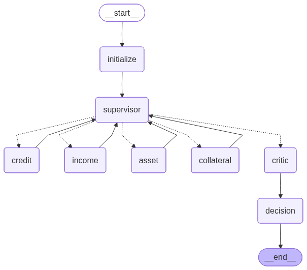

## 3️⃣ **Environment Setup**

**What you'll do:**

- Install required packages
- Set up API credentials
- Understand the technology stack

### 📦 **Technology Stack**

| Technology | Purpose |
| --- | --- |
| **LangGraph** | Agent orchestration & state management |
| **LangChain** | LLM integration & tool management |
| **OpenAI - GPT-4o-mini** | Language model for reasoning |
| **ChromaDB** | Vector store for policy retrieval |
| **Python** | Programming language |

### 🔧 **Installation Instructions**

Run the cell below to install all required packages. This may take 2-3 minutes.

```python
# 📦 Install Dependencies
# This will install all required packages for the mortgage underwriting system

%pip install \
  langgraph==1.1.9 \
  langchain==1.2.15 \
  langchain-openai==1.1.7 \
  langchain-community==0.4.1 \
  langchain-text-splitters==1.1.0 \
  chromadb==1.4.0 \
  pypdf==6.6.0

print("✅ All packages installed successfully!")
print("\n📚 Installed:")
print("  - LangGraph (Agent orchestration)")
print("  - LangChain (LLM workflows)")
print("  - LangChain Text Splitters")
print("  - ChromaDB (Vector storage)")
print("  - OpenAI Integration")
```

[output not shown]

### 🔑 **API Configuration**

```python
# 🔑 Configure GreatLearning API Keys
# Using GreatLearning's OpenAI proxy service

import os

# Load secrets from config.json (same folder as this notebook)
import json


# Load secrets from Colab
with open("config.json") as f:
    _secrets = json.load(f)

os.environ["OPENAI_API_KEY"]  = _secrets["API_KEY"]
os.environ["OPENAI_API_BASE"] = _secrets["OPENAI_API_BASE"]


print("✅ GreatLearning API configured via Colab Secrets!")
print("Using API Base:", os.environ["OPENAI_API_BASE"])
```

```
✅ GreatLearning API configured via Colab Secrets!
Using API Base: https://aibe.mygreatlearning.com/openai/v1
```

### 📚 **Import Required Libraries**

Now let's import all the libraries we'll need for building our multi-agent system.

```python
# 📚 Import Core Libraries

import json
import re
from typing import TypedDict, Annotated, List, Dict, Any, Optional
from datetime import datetime

# LangChain & LangGraph
from langgraph.graph import StateGraph, END
from langgraph.checkpoint.memory import MemorySaver
from langchain_openai import ChatOpenAI
from langchain_core.messages import HumanMessage, SystemMessage
from langchain.tools import tool

# Vector Store for RAG
from langchain_community.vectorstores import Chroma
from langchain_openai import OpenAIEmbeddings
from langchain_text_splitters import RecursiveCharacterTextSplitter
from langchain_community.document_loaders import PyPDFLoader


print("✅ All libraries imported successfully!")
print("\n🎉 Environment setup complete! You're ready to build the system.")
```

```
✅ All libraries imported successfully!

🎉 Environment setup complete! You're ready to build the system.
```

## 4️⃣ **Data Models & State Management**

### 🗂️ **Understanding State Management**

In a multi-agent system, **state** is the shared memory that all agents can read and write to. Think of it as a shared whiteboard where:

- Each agent writes their analysis results
- The supervisor tracks workflow progress
- The decision agent reads all findings to make final decision

### 💡 **Key Concepts**

**TypedDict**: Python's way of defining structured data with type hints

**Annotated**: Allows us to add metadata to fields (e.g., how to merge lists)

**State Graph**: LangGraph's state machine that manages workflow transitions

### 🏗️ **Define the State Schema**

Below we define the structure that will hold all data as it flows through our system.

```python
# 🏗️ Define Application State Schema

class UnderwritingState(TypedDict):
    """The complete state of a loan application as it moves through the system."""

    # Application Information
    case_id: str
    applicant_data: Dict[str, Any]
    sanitized_data: Dict[str, Any]

    # Agent Analysis Results
    credit_analysis: Optional[str]
    income_analysis: Optional[str]
    asset_analysis: Optional[str]
    collateral_analysis: Optional[str]

    # Coordination & Decision
    critic_review: Optional[str]
    decision_memo: Optional[str]
    final_decision: Optional[str]  # APPROVED, DENIED, CONDITIONAL_APPROVAL
    risk_score: Optional[int]  # 0-100

    # Workflow Control
    next_agent: Optional[str]
    analysis_complete: bool
    human_review_required: bool
    human_review_completed: bool
    human_notes: Optional[str]

    # Compliance
    bias_flags: List[str]
    policy_violations: List[str]

    # Audit Trail
    reasoning_chain: Annotated[List[str], "append"]  # Accumulates all reasoning steps
    timestamp: str

print("✅ State schema defined!")
print("\n📋 The state will track:")
print("  - Application data (sanitized and raw)")
print("  - All agent analyses")
print("  - Decision and risk assessment")
print("  - Compliance flags")
print("  - Complete audit trail")
```

```
✅ State schema defined!

📋 The state will track:
  - Application data (sanitized and raw)
  - All agent analyses
  - Decision and risk assessment
  - Compliance flags
  - Complete audit trail
```

## 5️⃣ **Building Core Components**

## 📝 **Part 1: Core Agent Implementation (10 marks)**

**What you'll build:**

- Utility tools for calculations (3 marks)
- PII sanitization system (2 marks)
- RAG policy retrieval (2 marks)
- Bias detection mechanism (2 marks)
- Test data preparation (1 mark)

### 🛠️ **Part A: Utility Tools**

These tools perform calculations that agents need. In LangChain, we use the `@tool` decorator to make functions available to AI agents.

**Why tools matter:**

- LLMs can't do precise math reliably
- Tools ensure accurate calculations
- Results are deterministic and auditable

```python
# 🛠️ Utility Tools for Underwriting Calculations

@tool
def calculate_dti_ratio(monthly_debt: float, monthly_income: float) -> str:
    """Calculate Debt-to-Income ratio.

    Args:
        monthly_debt: Total monthly debt obligations
        monthly_income: Total monthly gross income

    Returns:
        Formatted DTI ratio result
    """
    if monthly_income <= 0:
        return "Error: Monthly income must be greater than 0"

    dti = (monthly_debt / monthly_income) * 100

    result = {
        "dti_ratio": round(dti, 2),
        "monthly_debt": round(monthly_debt, 2),
        "monthly_income": round(monthly_income, 2),
        "status": "Acceptable" if dti <= 43 else "High" if dti <= 50 else "Excessive"
    }

    return f"DTI Ratio: {result['dti_ratio']}% ({result['status']}) - Debt: ${result['monthly_debt']:,.2f}, Income: ${result['monthly_income']:,.2f}"

@tool
def calculate_ltv_ratio(loan_amount: float, property_value: float) -> str:
    """Calculate Loan-to-Value ratio.

    Args:
        loan_amount: The loan amount requested
        property_value: Appraised value of the property

    Returns:
        Formatted LTV ratio result
    """
    if property_value <= 0:
        return "Error: Property value must be greater than 0"

    ltv = (loan_amount / property_value) * 100

    result = {
        "ltv_ratio": round(ltv, 2),
        "loan_amount": round(loan_amount, 2),
        "property_value": round(property_value, 2),
        "status": "Excellent" if ltv <= 80 else "Good" if ltv <= 90 else "High" if ltv <= 97 else "Excessive"
    }

    return f"LTV Ratio: {result['ltv_ratio']}% ({result['status']}) - Loan: ${result['loan_amount']:,.2f}, Value: ${result['property_value']:,.2f}"

@tool
def calculate_reserves(liquid_assets: float, monthly_payment: float, required_months: int = 2) -> str:
    """Calculate reserve coverage in months.

    Args:
        liquid_assets: Total liquid assets available
        monthly_payment: Monthly PITI payment
        required_months: Number of months reserves required (default 2)

    Returns:
        Formatted reserves analysis
    """
    if monthly_payment <= 0:
        return "Error: Monthly payment must be greater than 0"

    months_coverage = liquid_assets / monthly_payment
    required_amount = monthly_payment * required_months

    result = {
        "months_coverage": round(months_coverage, 1),
        "liquid_assets": round(liquid_assets, 2),
        "required_amount": round(required_amount, 2),
        "surplus_deficit": round(liquid_assets - required_amount, 2),
        "status": "Adequate" if months_coverage >= required_months else "Insufficient"
    }

    return f"Reserves: {result['months_coverage']} months coverage ({result['status']}) - Assets: ${result['liquid_assets']:,.2f}, Required: ${result['required_amount']:,.2f}"

@tool
def calculate_housing_expense_ratio(monthly_payment: float, monthly_income: float) -> str:
    """Calculate housing expense ratio (front-end ratio).

    Args:
        monthly_payment: Monthly PITI payment
        monthly_income: Total monthly gross income

    Returns:
        Formatted housing expense ratio
    """
    if monthly_income <= 0:
        return "Error: Monthly income must be greater than 0"

    ratio = (monthly_payment / monthly_income) * 100

    result = {
        "housing_ratio": round(ratio, 2),
        "monthly_payment": round(monthly_payment, 2),
        "monthly_income": round(monthly_income, 2),
        "status": "Acceptable" if ratio <= 28 else "Elevated" if ratio <= 35 else "High"
    }

    return f"Housing Ratio: {result['housing_ratio']}% ({result['status']}) - Payment: ${result['monthly_payment']:,.2f}, Income: ${result['monthly_income']:,.2f}"

@tool
def check_credit_score_policy(credit_score: int) -> str:
    """Check if credit score meets policy requirements.

    Args:
        credit_score: Borrower's credit score

    Returns:
        Policy compliance result
    """
    if credit_score >= 740:
        tier = "Excellent"
        rate_adjustment = "Best rates available"
    elif credit_score >= 700:
        tier = "Very Good"
        rate_adjustment = "Favorable rates"
    elif credit_score >= 660:
        tier = "Good"
        rate_adjustment = "Standard rates"
    elif credit_score >= 620:
        tier = "Fair"
        rate_adjustment = "Higher rates, may require compensating factors"
    else:
        tier = "Below Minimum"
        rate_adjustment = "Does not meet conventional loan requirements"

    return f"Credit Score: {credit_score} - Tier: {tier} - {rate_adjustment}"

@tool
def check_large_deposits(deposits: list, monthly_income: float) -> str:
    """Identify large deposits requiring sourcing documentation.

    Args:
        deposits: List of recent deposits [{'amount': float, 'date': str}, ...]
        monthly_income: Monthly income for threshold calculation

    Returns:
        Analysis of deposits requiring documentation
    """
    threshold = monthly_income * 0.25  # 25% of monthly income
    large_deposits = []

    for deposit in deposits:
        amount = deposit.get('amount', 0)
        if amount >= threshold:
            large_deposits.append({
                'amount': amount,
                'date': deposit.get('date', 'Unknown'),
                'sourcing_required': True
            })

    if not large_deposits:
        return f"No large deposits identified (threshold: ${threshold:,.2f}). All deposits are acceptable."

    result = f"Found {len(large_deposits)} large deposit(s) requiring documentation (threshold: ${threshold:,.2f}):\n"
    for i, dep in enumerate(large_deposits, 1):
        result += f"  {i}. ${dep['amount']:,.2f} on {dep['date']} - Sourcing documentation required\n"

    return result

@tool
def calculate_total_debt_obligations(debts: dict, proposed_payment: float) -> str:
    """Calculate total monthly debt obligations including proposed loan.

    Args:
        debts: Dictionary of current debts {'debt_name': amount, ...}
        proposed_payment: Proposed monthly loan payment

    Returns:
        Total debt calculation
    """
    current_debt = sum(debts.values())
    total_obligation = current_debt + proposed_payment

    result = {
        "current_debt": round(current_debt, 2),
        "proposed_payment": round(proposed_payment, 2),
        "total_obligation": round(total_obligation, 2),
        "debt_breakdown": {k: round(v, 2) for k, v in debts.items()}
    }

    breakdown = "\n".join([f"  - {k}: ${v:,.2f}" for k, v in result['debt_breakdown'].items()])

    return f"Total Monthly Obligations: ${result['total_obligation']:,.2f}\nCurrent Debt: ${result['current_debt']:,.2f}\n{breakdown}\nProposed Payment: ${result['proposed_payment']:,.2f}"

print("✅ Calculator tools created!")
print("\nAvailable tools:")
print("  • calculate_dti_ratio - DTI calculation")
print("  • calculate_ltv_ratio - LTV calculation")
print("  • calculate_reserves - Reserve coverage")
print("  • calculate_housing_expense_ratio - Front-end ratio")
print("  • check_credit_score_policy - Credit score tier")
print("  • check_large_deposits - Deposit sourcing")
print("  • calculate_total_debt_obligations - Total debt")
```

```
✅ Calculator tools created!

Available tools:
  • calculate_dti_ratio - DTI calculation
  • calculate_ltv_ratio - LTV calculation
  • calculate_reserves - Reserve coverage
  • calculate_housing_expense_ratio - Front-end ratio
  • check_credit_score_policy - Credit score tier
  • check_large_deposits - Deposit sourcing
  • calculate_total_debt_obligations - Total debt
```

### 🔒 **Part B: PII Sanitization**

**Why PII Sanitization Matters:**

- Protects borrower privacy
- Complies with data protection regulations (GDPR, CCPA)
- Reduces liability if external APIs are compromised

**What gets sanitized:**

- Social Security Numbers → `***-**-XXXX`
- Full names → `[APPLICANT_NAME]`
- Addresses → `[ADDRESS]`
- Phone numbers → `***-***-XXXX`

```python
# 🔒 PII Sanitization Functions

def sanitize_pii(data: Dict[str, Any]) -> Dict[str, Any]:
    """Remove or redact personally identifiable information.

    Args:
        data: Raw application data

    Returns:
        Sanitized data safe for LLM processing
    """
    sanitized = data.copy()

    # Redact SSN (keep last 4 digits)
    if 'ssn' in sanitized:
        ssn = sanitized['ssn']
        sanitized['ssn'] = f"***-**-{ssn[-4:]}" if len(ssn) >= 4 else "***-**-XXXX"

    # Replace full names with placeholders
    if 'name' in sanitized:
        sanitized['name'] = "[APPLICANT_NAME]"

    # Redact addresses
    if 'address' in sanitized:
        sanitized['address'] = "[ADDRESS]"

    # Mask phone numbers
    if 'phone' in sanitized:
        phone = sanitized['phone']
        sanitized['phone'] = f"***-***-{phone[-4:]}" if len(phone) >= 4 else "***-***-XXXX"

    return sanitized

def detect_bias_signals(analysis: str, applicant_data: Dict[str, Any]) -> List[str]:
    """Check for potential Fair Lending Act violations.

    Args:
        analysis: Agent's analysis text
        applicant_data: Applicant information

    Returns:
        List of detected bias flags
    """
    flags = []

    # Protected characteristics that shouldn't influence decisions
    protected_terms = [
        'race', 'color', 'religion', 'national origin',
        'sex', 'marital status', 'age', 'gender',
        'disability', 'familial status'
    ]

    # Check if analysis mentions protected characteristics
    analysis_lower = analysis.lower()
    for term in protected_terms:
        if term in analysis_lower:
            flags.append(f"Analysis mentions protected characteristic: {term}")

    # Check for zip code-based discrimination
    if 'zip' in applicant_data or 'zipcode' in applicant_data:
        if 'neighborhood' in analysis_lower or 'area' in analysis_lower:
            flags.append("Potential geographic bias - review for Fair Lending compliance")

    return flags

print("✅ PII sanitization system created!")
print("\n🛡️ Protection features:")
print("  - SSN redaction")
print("  - Name replacement")
print("  - Address masking")
print("  - Phone number protection")
print("  - Bias signal detection")
```

```
✅ PII sanitization system created!

🛡️ Protection features:
  - SSN redaction
  - Name replacement
  - Address masking
  - Phone number protection
  - Bias signal detection
```

### 📚 **Part C: RAG Policy Retrieval**

**What is RAG (Retrieval-Augmented Generation)?**

RAG allows our agents to retrieve relevant bank policies and guidelines dynamically. Instead of having all policies in the prompt (which would exceed token limits), we:

1. Store policies in a vector database (ChromaDB)
2. Convert queries to embeddings
3. Find the most relevant policy sections
4. Provide only relevant policies to the agent

**Benefits:**

- ✅ Handles thousands of pages of policies
- ✅ Always retrieves the most current guidelines
- ✅ Reduces context size for faster processing
- ✅ Easy to update when policies change

```python
def create_policy_store():
    """Create vector store with underwriting policies (loaded from PDF).

    Returns:
        ChromaDB vector store for policy retrieval
    """

    # Load policies from PDF instead of hardcoded text
    loader = PyPDFLoader("underwriting_policies.pdf")
    documents = loader.load()

    # Split policies into chunks
    text_splitter = RecursiveCharacterTextSplitter(chunk_size=1000, chunk_overlap=200)

    policy_chunks = text_splitter.split_documents(documents)

    # Create embeddings and store in ChromaDB
    embeddings = OpenAIEmbeddings(
        base_url="https://aibe.mygreatlearning.com/openai/v1"
    )

    vectorstore = Chroma.from_documents(
        documents=policy_chunks,
        embedding=embeddings
    )

    return vectorstore

def retrieve_relevant_policies(query: str, vectorstore) -> str:
    docs = vectorstore.similarity_search(query, k=6)

    section_map = {}

    for doc in docs:
        text = doc.page_content.strip()

        # Extract section heading like "2.3 Self-Employment Income"
        match = re.match(r"^\d+\.\d+\s+[A-Za-z ].+", text)
        section = match.group(0) if match else "OTHER"

        if section not in section_map:
            section_map[section] = text
        else:
            # append only new content
            if text not in section_map[section]:
                section_map[section] += "\n" + text

    return "\n\n".join(section_map.values())


# ✅ System initialization (unchanged usage)
vectorstore = create_policy_store()

print("✅ RAG policy system created!")
print("\n📖 Policy coverage:")
print("  - Credit guidelines")
print("  - Income verification rules")
print("  - Asset requirements")
print("  - Collateral standards")
```

```
✅ RAG policy system created!

📖 Policy coverage:
  - Credit guidelines
  - Income verification rules
  - Asset requirements
  - Collateral standards
```

```python
# 🧪 Test policy retrieval system

test_query = "What are the income verification requirements for self-employed borrowers?"

retrieved_policies = retrieve_relevant_policies(
    query=test_query,
    vectorstore=vectorstore
)

print(f"Test Query: {test_query}")
print("\nRetrieved relevant policy text:\n")
print(retrieved_policies[:1000], "...\n")  # truncate for readability
```

```
Test Query: What are the income verification requirements for self-employed borrowers?

Retrieved relevant policy text:

2.3 Self-Employment Income
Self-employed borrowers (25%+ ownership in business) require extensive documentation to verify
income stability and business viability:
 Tax Returns Required: Complete personal returns (1040) for 2 most recent years with all
schedules
 Business Returns: Business returns (1065, 1120, 1120S) for 2 years if applicable
 Year-to-Date P&L;: Current profit and loss statement and balance sheet prepared by
CPA/bookkeeper
 Business License: Copy of business license showing 2+ years of self-employment
 Income Calculation: IRS Form 1084 or similar; includes salary, distributions, non-recurring
expenses
 Income Trend: Income must be stable or increasing; declining income requires explanation
 CPA Letter: May be required for complex business structures or income calculations
New Self-Employment (Under 2 years): Businesses operating less than 2 years may be acceptable if

 CPA Letter: May be required for complex business structures or income calculations
New Self-Em ...
```

### 🧪 **Part D: Test Data Preparation**

Let's create three realistic test cases representing different scenarios:

1. **Strong applicant** - Should be approved
2. **Borderline case** - Requires careful review
3. **Weak applicant** - Likely denial

```python
# 🧪 Test Case Data - Loaded from JSON

# Load comprehensive test cases from JSON file
print("📁 Loading test cases from mortgage_test_cases.json...")

with open ("mortgage_test_cases.json") as f:
    test_data = json.load(f)

# Extract the three test cases
test_case_1 = test_data['test_cases'][0]  # Strong Approval - Sarah Johnson
test_case_2 = test_data['test_cases'][1]  # Marginal - Michael Chen
test_case_3 = test_data['test_cases'][2]  # Denial - Robert Martinez

print("✅ Test cases loaded successfully!\n")
print("🧪 Test Case Summary:")
print(f"  1. {test_case_1['case_id']}: {test_case_1['name']}")
print(f"     - Credit Score: {test_case_1['credit_score']}")
print(f"     - DTI Ratio: {test_case_1['dti_ratio']:.1%}")
print(f"     - Expected: {test_case_1['expected_decision']}\n")

print(f"  2. {test_case_2['case_id']}: {test_case_2['name']}")
print(f"     - Credit Score: {test_case_2['credit_score']}")
print(f"     - DTI Ratio: {test_case_2['dti_ratio']:.1%}")
print(f"     - Expected: {test_case_2['expected_decision']}\n")

print(f"  3. {test_case_3['case_id']}: {test_case_3['name']}")
print(f"     - Credit Score: {test_case_3['credit_score']}")
print(f"     - DTI Ratio: {test_case_3['dti_ratio']:.1%}")
print(f"     - Expected: {test_case_3['expected_decision']}\n")

print("📊 All test cases include comprehensive PII data:")
print("   ✓ Full names, SSN, email, phone, address")
print("   ✓ Detailed credit history with notes")
print("   ✓ Employment history and income details")
print("   ✓ Asset verification with deposit explanations")
print("   ✓ Property condition and repair requirements")
```

```
📁 Loading test cases from mortgage_test_cases.json...
✅ Test cases loaded successfully!

🧪 Test Case Summary:
  1. MTG-2025-001: Sarah Johnson
     - Credit Score: 760
     - DTI Ratio: 30.4%
     - Expected: APPROVED

  2. MTG-2025-002: Michael Chen
     - Credit Score: 680
     - DTI Ratio: 42.0%
     - Expected: CONDITIONAL

  3. MTG-2025-003: Robert Martinez
     - Credit Score: 595
     - DTI Ratio: 50.0%
     - Expected: REJECTED

📊 All test cases include comprehensive PII data:
   ✓ Full names, SSN, email, phone, address
   ✓ Detailed credit history with notes
   ✓ Employment history and income details
   ✓ Asset verification with deposit explanations
   ✓ Property condition and repair requirements
```

## 6️⃣ **Implementing Specialist Agents**

### 🤖 **Understanding Agent Architecture**

Each specialist agent follows the **ReAct (Reasoning + Acting)** pattern:

1. **Observe** - Receive application data and relevant policies
2. **Reason** - Analyze the data using domain expertise
3. **Act** - Use tools for calculations when needed
4. **Report** - Generate detailed analysis with recommendations

**Agent Components:**

- 📋 **System Prompt** - Defines agent's role and expertise
- 🛠️ **Tools** - Access to calculation functions
- 🧠 **LLM** - Language model for reasoning
- 📊 **State Access** - Can read/write to shared state

## 📝 **Part 2: Workflow & Orchestration (7 marks)**

**What you'll build:**

- Income Analyst Agent Implementation (1 mark)
- Asset Analyst Agent Implementation (1 mark)
- Collateral Analyst Agent Implementation (1 mark)
- Critic Agent Implementation (1 mark)
- Decision Agent Implementation (1 mark)
- Defining state and workflow/graph correctly (2 marks)

### 💳 **Agent 1: Credit Analyst**

**Responsibilities:**

- Evaluate credit score and history
- Assess borrower's willingness to repay
- Identify credit risk factors
- Recommend approval conditions

```python
# 🧠 Initialize Language Model with GreatLearning API

llm = ChatOpenAI(
    model="gpt-4o-mini",
    temperature=0,  # Deterministic for consistency
    base_url="https://aibe.mygreatlearning.com/openai/v1",  # GreatLearning API endpoint
)

# Create the policy store
policy_store = create_policy_store()

print("✅ LLM initialized with GreatLearning API!")
print("✅ Policy store created!")
```

```
✅ LLM initialized with GreatLearning API!
✅ Policy store created!
```

```python
# 🎯 Helper Functions for Agent Testing

def initialize_application(state: UnderwritingState) -> UnderwritingState:
    """
    Initialize a new application with sanitized data.
    """
    # Sanitize PII
    sanitized = sanitize_pii(state["applicant_data"])

    return {
        **state,
        "sanitized_data": sanitized,
        "analysis_complete": False,
        "human_review_required": False,
        "human_review_completed": False,
        "bias_flags": [],
        "policy_violations": [],
        "reasoning_chain": [f"Application {state.get('case_id')} initialized"],
        "timestamp": datetime.now().isoformat()
    }

def sanitize_pii_node(state: UnderwritingState) -> UnderwritingState:
    """
    Node wrapper for PII sanitization.
    """
    return state

print("✅ Helper functions for agent testing created!")
```

```
✅ Helper functions for agent testing created!
```

```python
# @title 1.💳 Credit Analyst Agent Implementation

def credit_analyst_node(state: UnderwritingState) -> UnderwritingState:
    """
    Analyzes borrower's credit profile and payment history.

    Evaluates:
    - Credit score quality
    - Payment history
    - Derogatory items (bankruptcies, foreclosures, collections)
    - Overall creditworthiness
    """
    # Retrieve relevant credit policies
    policies = retrieve_relevant_policies(
        "credit score requirements bankruptcies foreclosures late payments",
        policy_store
    )

    # Get sanitized application data
    app_data = state["sanitized_data"]

    # Use calculator tool for credit score assessment
    credit_score = app_data.get('credit_score', 0)
    credit_score_analysis = check_credit_score_policy.invoke({"credit_score": credit_score})

    # Build analysis prompt
    system_prompt = f"""
You are a Senior Credit Analyst with 15+ years of experience in mortgage underwriting.

RELEVANT POLICIES:
{policies}

Your task is to analyze the borrower's credit profile and provide a detailed assessment.

ANALYSIS FRAMEWORK:
1. Credit Score Assessment - Use provided assessment (DO NOT recalculate)
2. Payment History - Review late payments and patterns
3. Derogatory Items - Evaluate bankruptcies, foreclosures, collections
4. Policy Compliance - Check against credit guidelines
5. Risk Rating - Assign credit risk (Low/Medium/High)
6. Recommendations - Provide conditions or concerns

Be thorough, objective, and policy-compliant. Support conclusions with data.
IMPORTANT: Use the EXACT credit score assessment provided below. Do not recalculate.
"""

    user_prompt = f"""
Analyze the credit profile for case {app_data.get('case_id')}:

CALCULATED CREDIT SCORE ASSESSMENT (ACCURATE - DO NOT RECALCULATE):
{credit_score_analysis}

CREDIT HISTORY DATA:
- Bankruptcies: {app_data.get('credit_history', {}).get('bankruptcies', 0)}
- Foreclosures: {app_data.get('credit_history', {}).get('foreclosures', 0)}
- Late Payments (12mo): {app_data.get('credit_history', {}).get('late_payments_12mo', 0)}
- Collections: {app_data.get('credit_history', {}).get('collections', [])}

Provide your detailed credit analysis based on the ACCURATE assessment above.
"""

    # Generate analysis using llm directly
    response = llm.invoke([
        SystemMessage(content=system_prompt),
        HumanMessage(content=user_prompt)
    ])

    # Extract analysis text
    analysis = response.content

    # Check for bias signals
    bias_flags = detect_bias_signals(analysis, app_data)

    # Update state
    return {
        **state,
        "credit_analysis": analysis,
        "bias_flags": state.get("bias_flags", []) + bias_flags,
        "reasoning_chain": state.get("reasoning_chain", []) + [
            f"Credit Analyst: Completed credit analysis for {app_data.get('case_id')}"
        ]
    }

print("✅ Credit Analyst Agent created!")
```

```
✅ Credit Analyst Agent created!
```

```python
# @title 🧪 Test Case 01 - Credit Analyst Workflow

print("="*80)
print("TEST CASE 01: CREDIT ANALYST - Workflow Demonstration")
print("="*80)
print()

print("📋 OBJECTIVE: Demonstrate Credit Analyst's responsibilities and analysis")
print()

# Create a minimal workflow with just Credit Analyst

# Initialize state ONCE
initial_inputs = {
    "case_id": test_case_1["case_id"],
    "applicant_data": test_case_1,
    "sanitized_data": {},
    "credit_analysis": None,
    "income_analysis": None,
    "asset_analysis": None,
    "collateral_analysis": None,
    "critic_review": None,
    "decision_memo": None,
    "final_decision": None,
    "risk_score": None,
    "next_agent": None,
    "analysis_complete": False,
    "human_review_required": False,
    "human_review_completed": False,
    "human_notes": None,
    "bias_flags": [],
    "policy_violations": [],
    "reasoning_chain": [],
    "timestamp": datetime.now().isoformat()
}

# Run initialization
TC_01_state_0 = initialize_application(initial_inputs)
TC_01_state_0 = sanitize_pii_node(TC_01_state_0)

# Run Credit Analyst
TC_01_state_1 = credit_analyst_node(TC_01_state_0)

# Use TC_01_state_1 instead of result
result = TC_01_state_1

# Execute

print("="*80)
print("📊 CREDIT ANALYST RESULTS")
print("="*80)
print()

print("📌 Case ID:", result.get("case_id"))
print()

print("💳 CREDIT ANALYSIS:")
print("-" * 80)
print(result.get("credit_analysis", "No analysis generated"))
print()

print("🚩 Bias Flags:", len(result.get("bias_flags", [])))
if result.get("bias_flags"):
    for flag in result.get("bias_flags", []):
        print(f"   ⚠️ {flag}")
print()

print("🔍 Reasoning Chain:")
for step in result.get("reasoning_chain", []):
    print(f"   → {step}")
print()

print("="*80)
print("✅ Credit Analyst Test Complete!")
print("="*80)
print()
print("🎓 LEARNER NOTE:")
print("   The Credit Analyst evaluates:")
print("   • Credit score quality and history")
print("   • Payment patterns and derogatory items")
print("   • Compliance with lending policies")
print("   • Risk rating for creditworthiness")
print()
```

```
================================================================================
TEST CASE 01: CREDIT ANALYST - Workflow Demonstration
================================================================================

📋 OBJECTIVE: Demonstrate Credit Analyst's responsibilities and analysis

================================================================================
📊 CREDIT ANALYST RESULTS
================================================================================

📌 Case ID: MTG-2025-001

💳 CREDIT ANALYSIS:
--------------------------------------------------------------------------------
### Credit Profile Analysis for Case MTG-2025-001

#### 1. Credit Score Assessment
- **Credit Score**: 760
- **Tier**: Excellent
- **Assessment**: The borrower falls into the "Excellent" credit tier, which qualifies them for the best available rates. This score indicates a strong credit history and responsible credit management.

#### 2. Payment History
- **Late Payments (12 months)**: 0
- **Assessment**: The absence of late payments in the past 12 months demonstrates a solid payment history. This is a positive indicator of the borrower’s reliability and ability to manage their financial obligations.

#### 3. Derogatory Items
- **Bankruptcies**: 0
- **Foreclosures**: 0
- **Collections**: []
- **Assessment**: The borrower has no bankruptcies, foreclosures, or collections on their credit report. This clean record further supports their strong creditworthiness and indicates a low risk of default.

#### 4. Policy Compliance
- **Jumbo Loan Eligibility**: With a credit score of 760, the borrower meets the minimum credit score requirement for Jumbo loans (700), and they are also eligible for programs requiring a score of 720+.
- **Assessment**: The borrower is fully compliant with the credit guidelines for Jumbo loans, making them a strong candidate for mortgage approval.

#### 5. Risk Rating
- **Risk Rating**: Low
- **Assessment**: Given the excellent credit score, clean payment history, and absence of derogatory items, the borrower is assessed as a low-risk candidate for mortgage lending.

#### 6. Recommendations
```

[output cut: 8 more lines]

```

🔍 Reasoning Chain:
   → Application MTG-2025-001 initialized
   → Credit Analyst: Completed credit analysis for MTG-2025-001

================================================================================
✅ Credit Analyst Test Complete!
================================================================================

🎓 LEARNER NOTE:
   The Credit Analyst evaluates:
   • Credit score quality and history
   • Payment patterns and derogatory items
   • Compliance with lending policies
   • Risk rating for creditworthiness
```

### **Task:** Write System and User Prompts for Income Analyst Agent

Write a **system prompt** and **user prompt** for the Income Analyst Agent that includes this analysis framework:

#### ANALYSIS FRAMEWORK:

1. **Employment Stability** - Review job history and tenure
2. **Income Verification** - Validate income sources
3. **DTI Calculation** - Use provided calculation (DO NOT recalculate)
4. **Payment Capacity** - Assess affordability
5. **Risk Assessment** - Identify income risks
6. **Recommendations** - Provide conditions if needed

#### Requirements:

- **System prompt**: Define the agent's role, inject RAG policies, provide the framework above, and emphasize using exact calculations without recalculating
- **User prompt**: Present employment data, pre-calculated DTI/housing ratios, and debt obligations with clear formatting and section headers

```python
# @title 2.💵 Income Analyst Agent Implementation
def income_analyst_node(state: UnderwritingState) -> UnderwritingState:
    """
    Analyzes borrower's income stability and capacity to repay.

    Evaluates:
    - Employment history and stability
    - Income sources and verification
    - Debt-to-Income ratio
    - Capacity for monthly payment
    """
    # Retrieve income policies
    policies = retrieve_relevant_policies(
        "employment income verification DTI ratio self-employed",
        policy_store
    )

    app_data = state["sanitized_data"]

    # Use calculator tools for accurate calculations
    debts = app_data.get('debts', {})
    proposed_payment = app_data.get('loan', {}).get('estimated_payment', 0)
    monthly_income = app_data.get('employment', {}).get('monthly_income', 0)

    # Calculate using tools (eliminates hallucinations)
    total_debt = sum(debts.values())
    dti_result = calculate_dti_ratio.invoke({
        "monthly_debt": total_debt + proposed_payment,
        "monthly_income": monthly_income
    })

    housing_ratio_result = calculate_housing_expense_ratio.invoke({
        "monthly_payment": proposed_payment,
        "monthly_income": monthly_income
    })

    debt_breakdown = calculate_total_debt_obligations.invoke({
        "debts": debts,
        "proposed_payment": proposed_payment
    })

    system_prompt = f"""

You are a Senior Income Analyst with 15+ years of experience in mortgage underwriting.

RELEVANT POLICIES:
{policies}

Your task is to analyze the borrower's income stability and capacity to repay the loan.

ANALYSIS FRAMEWORK:
1. Employment Stability - Review job history and tenure
2. Income Verification - Validate income sources
3. DTI Calculation - Use provided calculation (DO NOT recalculate)
4. Payment Capacity - Assess affordability of the proposed payment
5. Risk Assessment - Identify income-related risks
6. Recommendations - Provide conditions if needed

Be thorough, objective, and policy-compliant. Support conclusions with data.
IMPORTANT: Use the EXACT DTI, housing ratio, and debt calculations provided below.
Do not recalculate any figures.

"""

    user_prompt = f"""

Analyze the income profile for case {app_data.get('case_id')}:

EMPLOYMENT DATA:
- Employer: {app_data.get('employment', {}).get('employer', 'N/A')}
- Job Title: {app_data.get('employment', {}).get('job_title', 'N/A')}
- Employment Type: {app_data.get('employment', {}).get('employment_type', 'N/A')}
- Years Employed: {app_data.get('employment', {}).get('years_employed', 'N/A')}
- Monthly Income: ${monthly_income:,.2f}

CALCULATED DTI RATIO (ACCURATE - DO NOT RECALCULATE):
{dti_result}

CALCULATED HOUSING EXPENSE RATIO (ACCURATE - DO NOT RECALCULATE):
{housing_ratio_result}

TOTAL DEBT OBLIGATIONS (ACCURATE - DO NOT RECALCULATE):
{debt_breakdown}

PROPOSED MONTHLY PAYMENT: ${proposed_payment:,.2f}

Provide your detailed income analysis based on the ACCURATE calculations above.

"""

    # Generate analysis using llm directly
    response = llm.invoke([
        SystemMessage(content=system_prompt),
        HumanMessage(content=user_prompt)
    ])

    analysis = response.content
    bias_flags = detect_bias_signals(analysis, app_data)

    return {
        **state,
        "income_analysis": analysis,
        "bias_flags": state.get("bias_flags", []) + bias_flags,
        "reasoning_chain": state.get("reasoning_chain", []) + [
            f"Income Analyst: Completed income analysis with DTI calculation"
        ]
    }

print("✅ Income Analyst Agent created!")
```

```
✅ Income Analyst Agent created!
```

```python
# @title 🧪 Test Case 01 - Income Analyst Workflow

print("="*80)
print("TEST CASE 01: INCOME ANALYST - Workflow Demonstration")
print("="*80)
print()

print("📋 OBJECTIVE: Demonstrate Income Analyst's DTI calculation and income verification")
print()

# Create workflow with Credit and Income Analysts

# Use state from previous agent (Credit Analyst)
TC_01_state_2 = income_analyst_node(TC_01_state_1)

# Use TC_01_state_2 instead of result
result = TC_01_state_2

print("="*80)
print("📊 INCOME ANALYST RESULTS")
print("="*80)
print()

print("📌 Case ID:", result.get("case_id"))
print()

# Show income-specific details
app_data = test_case_1
debts = app_data.get('debts', {})
total_debt = sum(debts.values())
monthly_income = app_data.get('employment', {}).get('monthly_income', 0)
proposed_payment = app_data.get('loan', {}).get('estimated_payment', 0)

print("💵 INCOME DATA:")
print(f"   • Monthly Income: ${monthly_income:,.2f}")
print(f"   • Current Debt: ${total_debt:,.2f}")
print(f"   • Proposed Payment: ${proposed_payment:,.2f}")
print(f"   • DTI Ratio: {((total_debt + proposed_payment) / monthly_income * 100):.2f}%")
print()

print("💵 INCOME ANALYSIS:")
print("-" * 80)
print(result.get("income_analysis", "No analysis generated"))
print()

print("🔍 Reasoning Chain:")
for step in result.get("reasoning_chain", []):
    if "Income" in step:
        print(f"   → {step}")
print()

print("="*80)
print("✅ Income Analyst Test Complete!")
print("="*80)
print()
print("🎓 LEARNER NOTE:")
print("   The Income Analyst evaluates:")
print("   • Employment stability and tenure")
print("   • Income verification and sources")
print("   • Debt-to-Income (DTI) ratio calculation")
print("   • Capacity to afford monthly payments")
print()
```

```
================================================================================
TEST CASE 01: INCOME ANALYST - Workflow Demonstration
================================================================================

📋 OBJECTIVE: Demonstrate Income Analyst's DTI calculation and income verification

================================================================================
📊 INCOME ANALYST RESULTS
================================================================================

📌 Case ID: MTG-2025-001

💵 INCOME DATA:
   • Monthly Income: $12,500.00
   • Current Debt: $7,600.00
   • Proposed Payment: $3,200.00
   • DTI Ratio: 86.40%

💵 INCOME ANALYSIS:
--------------------------------------------------------------------------------
### Income Analysis for Case MTG-2025-001

#### 1. Employment Stability
- **Employer**: Tech Solutions Inc
- **Job Title**: Not provided
- **Employment Type**: Not provided
- **Years Employed**: Not provided
- **Monthly Income**: $12,500.00

**Analysis**: The lack of specific employment details such as job title, employment type, and years employed raises concerns regarding employment stability. Without this information, it is difficult to assess the reliability of the income source.

#### 2. Income Verification
- **Monthly Income**: $12,500.00

**Analysis**: The income appears to be substantial; however, without additional documentation (e.g., pay stubs, tax returns, or employer verification), it is challenging to validate the source and sustainability of this income. The absence of a job title and employment type further complicates the v…

#### 3. DTI Calculation
- **DTI Ratio**: 86.4% (Excessive)
- **Total Monthly Obligations**: $10,800.00
- **Income**: $12,500.00
```

[output cut: 27 more lines]

```
**Conclusion**: The borrower's income profile presents significant risks due to the excessive DTI ratio and lack of employment stability documentation. It is recommended to gather further information and consider conditions to ensure the borrower's ability to repay the loan.

🔍 Reasoning Chain:
   → Income Analyst: Completed income analysis with DTI calculation

================================================================================
✅ Income Analyst Test Complete!
================================================================================

🎓 LEARNER NOTE:
   The Income Analyst evaluates:
   • Employment stability and tenure
   • Income verification and sources
   • Debt-to-Income (DTI) ratio calculation
   • Capacity to afford monthly payments
```

### **Task:** Write System and User Prompts for Asset Analyst Agent

#### ANALYSIS FRAMEWORK:

1. **Down Payment Adequacy** - Verify sufficient funds
2. **Reserve Requirements** - Use provided calculation
3. **Large Deposits** - Use provided analysis
4. **Source of Funds** - Ensure proper sourcing
5. **Risk Assessment** - Identify asset-related risks
6. **Documentation Needs** - List required documents

#### Requirements:

- **System prompt**: Define the agent's role and expertise, include relevant policies from the retrieval system, provide the analysis framework, and emphasize that the agent should use pre-calculated metrics without recalculating them
- **User prompt**: Present the applicant's asset information in organized sections, include loan requirement details, and provide pre-calculated metrics from tool functions with clear warnings against recalculation

```python
# @title 3.💰 Asset Analyst Agent Implementation

def asset_analyst_node(state: UnderwritingState) -> UnderwritingState:
    """
    Analyzes borrower's assets and reserves.

    Evaluates:
    - Down payment source and adequacy
    - Reserve funds for emergencies
    - Large deposit sourcing
    - Asset documentation
    """
    policies = retrieve_relevant_policies(
        "down payment reserves assets large deposits gift funds",
        policy_store
    )

    app_data = state["sanitized_data"]
    assets = app_data.get('assets', {})
    loan = app_data.get('loan', {})
    monthly_income = app_data.get('employment', {}).get('monthly_income', 0)

    # Use calculator tools for accurate calculations
    liquid_assets = assets.get('checking', 0) + assets.get('savings', 0)
    monthly_payment = loan.get('estimated_payment', 0)

    reserves_result = calculate_reserves.invoke(
        {
            "liquid_assets": liquid_assets,
            "monthly_payment": monthly_payment
        }
    )

    deposits_result = check_large_deposits.invoke({
        "deposits": assets.get('recent_deposits', []),
        "monthly_income": monthly_income
    })

    system_prompt = f"""

You are a Senior Asset Analyst with 15+ years of experience in mortgage underwriting.

RELEVANT POLICIES:
{policies}

Your task is to analyze the borrower's assets, reserves, and source of funds.

ANALYSIS FRAMEWORK:
1. Down Payment Adequacy - Verify sufficient funds for the down payment
2. Reserve Requirements - Use provided calculation (DO NOT recalculate)
3. Large Deposits - Use provided analysis (DO NOT recalculate)
4. Source of Funds - Ensure all funds are properly sourced
5. Risk Assessment - Identify asset-related risks
6. Documentation Needs - List required supporting documents

Be thorough, objective, and policy-compliant. Support conclusions with data.
IMPORTANT: Use the EXACT reserve and deposit calculations provided below.
Do not recalculate any figures.

"""

    user_prompt = f"""

Analyze the asset profile for case {app_data.get('case_id')}:

ASSET DATA:
- Checking: ${assets.get('checking', 0):,.2f}
- Savings: ${assets.get('savings', 0):,.2f}
- Total Liquid Assets: ${liquid_assets:,.2f}
- Recent Deposits: {assets.get('recent_deposits', [])}

LOAN REQUIREMENTS:
- Loan Amount: ${loan.get('amount', 0):,.2f}
- Down Payment: ${loan.get('down_payment', 0):,.2f}
- Estimated Monthly Payment: ${monthly_payment:,.2f}

CALCULATED RESERVE COVERAGE (ACCURATE - DO NOT RECALCULATE):
{reserves_result}

LARGE DEPOSIT ANALYSIS (ACCURATE - DO NOT RECALCULATE):
{deposits_result}

Provide your detailed asset analysis based on the ACCURATE calculations above.

"""

    # Generate analysis using llm directly
    response = llm.invoke([
        SystemMessage(content=system_prompt),
        HumanMessage(content=user_prompt)
    ])

    analysis = response.content
    bias_flags = detect_bias_signals(analysis, app_data)

    return {
        **state,
        "asset_analysis": analysis,
        "bias_flags": state.get("bias_flags", []) + bias_flags,
        "reasoning_chain": state.get("reasoning_chain", []) + [
            f"Asset Analyst: Completed asset analysis and deposit review"
        ]
    }

print("✅ Asset Analyst Agent created!")
```

```
✅ Asset Analyst Agent created!
```

```python
# @title 🧪 Test Case 01 - Asset Analyst Workflow

print("="*80)
print("TEST CASE 01: ASSET ANALYST - Workflow Demonstration")
print("="*80)
print()

print("📋 OBJECTIVE: Demonstrate Asset Analyst's fund verification and deposit analysis")
print()

# Create workflow through Asset Analyst

# Use state from previous agent (Income Analyst)
TC_01_state_3 = asset_analyst_node(TC_01_state_2)

# Use TC_01_state_3 instead of result
result = TC_01_state_3

print("="*80)
print("📊 ASSET ANALYST RESULTS")
print("="*80)
print()

print("📌 Case ID:", result.get("case_id"))
print()

# Show asset-specific details
assets = test_case_1.get('assets', {})
loan = test_case_1.get('loan', {})
total_liquid = assets.get('checking', 0) + assets.get('savings', 0)

print("💰 ASSET DATA:")
print(f"   • Liquid Assets: ${total_liquid:,.2f}")
print(f"   • Required Down Payment: ${loan.get('down_payment', 0):,.2f}")
print(f"   • Coverage: {(total_liquid / loan.get('down_payment', 1) * 100):.1f}%")
print()

print("💰 ASSET ANALYSIS:")
print("-" * 80)
print(result.get("asset_analysis", "No analysis generated"))
print()

print("🔍 Reasoning Chain:")
for step in result.get("reasoning_chain", []):
    if "Asset" in step:
        print(f"   → {step}")
print()

print("="*80)
print("✅ Asset Analyst Test Complete!")
print("="*80)
print()
print("🎓 LEARNER NOTE:")
print("   The Asset Analyst evaluates:")
print("   • Down payment adequacy and sourcing")
print("   • Reserve funds for emergencies")
print("   • Large deposit verification")
print("   • Asset documentation requirements")
print()
```

```
================================================================================
TEST CASE 01: ASSET ANALYST - Workflow Demonstration
================================================================================

📋 OBJECTIVE: Demonstrate Asset Analyst's fund verification and deposit analysis

================================================================================
📊 ASSET ANALYST RESULTS
================================================================================

📌 Case ID: MTG-2025-001

💰 ASSET DATA:
   • Liquid Assets: $185,000.00
   • Required Down Payment: $100,000.00
   • Coverage: 185.0%

💰 ASSET ANALYSIS:
--------------------------------------------------------------------------------
### Asset Profile Analysis for Case MTG-2025-001

#### 1. Down Payment Adequacy
- **Total Liquid Assets**: $185,000.00
- **Required Down Payment**: $100,000.00
- **Analysis**: The borrower has sufficient funds for the down payment, with a total of $185,000.00 available, which exceeds the required down payment of $100,000.00. This indicates a strong financial position regarding the down payment requirement.

#### 2. Reserve Requirements
- **Calculated Reserves**: 57.8 months coverage (Adequate)
- **Assets**: $185,000.00
- **Required Reserves**: $6,400.00
- **Analysis**: The borrower meets the reserve requirements significantly, with 57.8 months of coverage compared to the required 6,400.00. This indicates a robust financial cushion, providing assurance of the borrower’s ability to manage ongoing payments and financial obligations.

#### 3. Large Deposits
- **Threshold for Large Deposits**: $3,125.00
- **Identified Large Deposits**:
  1. **$22,000.00 on 2024-12-15** - Sourcing documentation required
  2. **$12,500.00 on 2024-11-30** - Sourcing documentation required
  3. **$12,500.00 on 2024-10-30** - Sourcing documentation required
- **Analysis**: Three large deposits have been identified that exceed the threshold. Each of these deposits requires sourcing documentation to verify their legitimacy and ensure they are acceptable under the policy guidelines. The borrower must provide explanations and supporting documents for these…

```

[output cut: 16 more lines]

```
The borrower demonstrates a strong asset profile with adequate funds for the down payment and reserves. However, the large deposits require careful sourcing to ensure compliance with underwriting policies. Addressing the documentation needs will be crucial in mitigating any potential risks associate…

🔍 Reasoning Chain:
   → Asset Analyst: Completed asset analysis and deposit review

================================================================================
✅ Asset Analyst Test Complete!
================================================================================

🎓 LEARNER NOTE:
   The Asset Analyst evaluates:
   • Down payment adequacy and sourcing
   • Reserve funds for emergencies
   • Large deposit verification
   • Asset documentation requirements
```

```python
# @title 4.🏠 Collateral Analyst Agent Implementation

def collateral_analyst_node (state: UnderwritingState) -> UnderwritingState:
    """
    Analyzes property value and condition.

    Evaluates:
    - Property appraisal and value
    - Loan-to-Value ratio
    - Property condition and habitability
    - Collateral adequacy
    """
    policies = retrieve_relevant_policies(
        "appraisal property condition LTV collateral",
        policy_store
    )

    app_data = state["sanitized_data"]
    property_data = app_data.get('property', {})
    loan = app_data.get('loan', {})

    # Use calculator tool for accurate LTV calculation
    loan_amount = loan.get('amount', 0)
    appraised_value = property_data.get('appraised_value', 0)

    ltv_result = calculate_ltv_ratio.invoke({
        "loan_amount": loan_amount,
        "property_value": appraised_value
    })

    system_prompt = f"""
You are a Senior Collateral Analyst with expertise in property valuation.

RELEVANT POLICIES:
{policies}

Your task is to assess the property as collateral for the loan.

ANALYSIS FRAMEWORK:
1. Appraisal Review - Validate property value
2. LTV Calculation - Use provided calculation (DO NOT recalculate)
3. Property Condition - Evaluate habitability
4. Marketability - Consider market factors
5. Risk Assessment - Identify collateral risks
6. Recommendations - Note any concerns

IMPORTANT: Use the EXACT LTV calculation provided below. Do not recalculate.
"""

    user_prompt = f"""
Analyze property collateral for case {app_data.get('case_id')}:

PROPERTY:
- Type: {property_data.get('type')}
- Appraised Value: ${appraised_value:,.2f}
- Condition: {property_data.get('condition')}
- Use: {loan.get('use')}

LOAN:
- Loan Amount: ${loan_amount:,.2f}
- Down Payment: ${loan.get('down_payment', 0):,.2f}

CALCULATED LTV (ACCURATE - DO NOT RECALCULATE):
{ltv_result}

Provide your collateral analysis based on this ACCURATE calculation.
"""

    # Generate analysis using llm directly
    response = llm.invoke([
        SystemMessage(content=system_prompt),
        HumanMessage(content=user_prompt)
    ])

    analysis = response.content
    bias_flags = detect_bias_signals(analysis, app_data)

    return {
        **state,
        "collateral_analysis": analysis,
        "bias_flags": state.get("bias_flags", []) + bias_flags,
        "reasoning_chain": state.get("reasoning_chain", []) + [
            f"Collateral Analyst: Completed property analysis (LTV from tool)"
        ]
    }

print("✅ Collateral Analyst Agent created!")
```

```
✅ Collateral Analyst Agent created!
```

```python
# @title 🧪 Test Case 01 - Collateral Analyst Workflow

print("="*80)
print("TEST CASE 01: COLLATERAL ANALYST - Workflow Demonstration")
print("="*80)
print()

print("📋 OBJECTIVE: Demonstrate Collateral Analyst's property evaluation and LTV calculation")
print()

# Create workflow through Collateral Analyst

# Use state from previous agent (Asset Analyst)
TC_01_state_4 = collateral_analyst_node(TC_01_state_3)

# Use TC_01_state_4 instead of result
result = TC_01_state_4

print("="*80)
print("📊 COLLATERAL ANALYST RESULTS")
print("="*80)
print()

print("📌 Case ID:", result.get("case_id"))
print()

# Show property-specific details
property_data = test_case_1.get('property', {})
loan = test_case_1.get('loan', {})
loan_amount = loan.get('amount', 0)
appraised_value = property_data.get('appraised_value', 0)
ltv = (loan_amount / appraised_value * 100) if appraised_value > 0 else 0

print("🏠 PROPERTY DATA:")
print(f"   • Appraised Value: ${appraised_value:,.2f}")
print(f"   • Loan Amount: ${loan_amount:,.2f}")
print(f"   • LTV Ratio: {ltv:.2f}%")
print(f"   • Property Condition: {property_data.get('condition')}")
print()

print("🏠 COLLATERAL ANALYSIS:")
print("-" * 80)
print(result.get("collateral_analysis", "No analysis generated"))
print()

print("🔍 Reasoning Chain:")
for step in result.get("reasoning_chain", []):
    if "Collateral" in step:
        print(f"   → {step}")
print()

print("="*80)
print("✅ Collateral Analyst Test Complete!")
print("="*80)
print()
print("🎓 LEARNER NOTE:")
print("   The Collateral Analyst evaluates:")
print("   • Property appraisal and value")
print("   • Loan-to-Value (LTV) ratio")
print("   • Property condition and habitability")
print("   • Collateral adequacy for the loan")
print()
```

```
================================================================================
TEST CASE 01: COLLATERAL ANALYST - Workflow Demonstration
================================================================================

📋 OBJECTIVE: Demonstrate Collateral Analyst's property evaluation and LTV calculation

================================================================================
📊 COLLATERAL ANALYST RESULTS
================================================================================

📌 Case ID: MTG-2025-001

🏠 PROPERTY DATA:
   • Appraised Value: $515,000.00
   • Loan Amount: $400,000.00
   • LTV Ratio: 77.67%
   • Property Condition: C3 - Average

🏠 COLLATERAL ANALYSIS:
--------------------------------------------------------------------------------
### Collateral Analysis for Case MTG-2025-001

#### 1. Appraisal Review
- **Appraised Value**: The property has been appraised at $515,000. This value is essential for determining the adequacy of collateral for the loan amount.
- **Condition**: The property is rated as C3 - Average, indicating that it is in acceptable condition but may require some minor repairs or updates to enhance its marketability and value retention.

#### 2. LTV Calculation
- **LTV Ratio**: 77.67% (Excellent)
  - **Loan Amount**: $400,000
  - **Appraised Value**: $515,000
- This LTV ratio is within acceptable limits, indicating that the loan amount is well-supported by the property value, providing a cushion for the lender in case of default.

#### 3. Property Condition
- The average condition (C3) suggests that while the property is habitable, it may not be in pristine condition. It is important to ensure that there are no significant deferred maintenance issues that could affect safety or structural integrity.
- **Mechanical Systems**: It is assumed that all mechanical systems (heating, cooling, plumbing, electrical) are functional, as there are no indications of issues in the appraisal.
- **Health Hazards**: There are no known health hazards reported, which is crucial for ensuring the property meets safety standards.

#### 4. Marketability
- The property type (Single Family Home) is highly marketable and generally has a strong demand in the housing market. This is beneficial for the loan's collateral value.
- Given the appraised value and the average condition, the property should attract potential buyers if needed, maintaining its marketability.
```

[output cut: 12 more lines]

```
In conclusion, the property meets the necessary collateral requirements for the loan, with a solid LTV ratio and acceptable condition. However, attention should be given to maintaining the property to mitigate any potential risks.

🔍 Reasoning Chain:
   → Collateral Analyst: Completed property analysis (LTV from tool)

================================================================================
✅ Collateral Analyst Test Complete!
================================================================================

🎓 LEARNER NOTE:
   The Collateral Analyst evaluates:
   • Property appraisal and value
   • Loan-to-Value (LTV) ratio
   • Property condition and habitability
   • Collateral adequacy for the loan
```

```python
# @title 5.🔎 Critic Agent Implementation

def critic_agent_node (state: UnderwritingState) -> UnderwritingState:
    """
    Reviews all specialist analyses for consistency and completeness.

    Checks:
    - All analyses are complete
    - No contradictions between analysts
    - Policy compliance across all areas
    - Identifies gaps or concerns
    """
    system_prompt = """
You are a Quality Assurance Critic reviewing underwriting analyses.

Your role is to:
1. Verify all analyses are complete and thorough
2. Identify any contradictions or inconsistencies
3. Ensure policy compliance
4. Flag any missing information
5. Provide a synthesis of key findings

Be critical but fair. Focus on ensuring decision quality.
"""

    user_prompt = f"""
Review all analyses for case {state.get('case_id')}:

CREDIT ANALYSIS:
{state.get('credit_analysis', 'Not completed')}

INCOME ANALYSIS:
{state.get('income_analysis', 'Not completed')}

ASSET ANALYSIS:
{state.get('asset_analysis', 'Not completed')}

COLLATERAL ANALYSIS:
{state.get('collateral_analysis', 'Not completed')}

BIAS FLAGS:
{state.get('bias_flags', [])}

Provide your critical review and synthesis.
"""

    # Generate review using llm directly
    response = llm.invoke([
        SystemMessage(content=system_prompt),
        HumanMessage(content=user_prompt)
    ])

    return {
        **state,
        "critic_review": response.content,
        "reasoning_chain": state.get("reasoning_chain", []) + [
            "Critic: Completed review of all specialist analyses"
        ]
    }

print("✅ Critic Agent created!")
```

```
✅ Critic Agent created!
```

```python
# @title 🧪 Test Case 01 - Critic Agent Workflow

print("="*80)
print("TEST CASE 01: CRITIC AGENT - Workflow Demonstration")
print("="*80)
print()

print("📋 OBJECTIVE: Demonstrate Critic Agent's quality assurance and synthesis")
print()

# Create workflow through Critic Agent

# Use state from previous agent (Collateral Analyst)
TC_01_state_5 = critic_agent_node(TC_01_state_4)

# Use TC_01_state_5 instead of result
result = TC_01_state_5

print("="*80)
print("📊 CRITIC AGENT RESULTS")
print("="*80)
print()

print("📌 Case ID:", result.get("case_id"))
print()

print("🔎 CRITIC REVIEW:")
print("-" * 80)
print(result.get("critic_review", "No review generated"))
print()

print("📋 ANALYSES REVIEWED:")
print(f"   • Credit Analysis: {'✅ Complete' if result.get('credit_analysis') else '❌ Missing'}")
print(f"   • Income Analysis: {'✅ Complete' if result.get('income_analysis') else '❌ Missing'}")
print(f"   • Asset Analysis: {'✅ Complete' if result.get('asset_analysis') else '❌ Missing'}")
print(f"   • Collateral Analysis: {'✅ Complete' if result.get('collateral_analysis') else '❌ Missing'}")
print()

print("🚩 Bias Flags Found:", len(result.get("bias_flags", [])))
print()

print("🔍 Reasoning Chain:")
for step in result.get("reasoning_chain", []):
    if "Critic" in step:
        print(f"   → {step}")
print()

print("="*80)
print("✅ Critic Agent Test Complete!")
print("="*80)
print()
print("🎓 LEARNER NOTE:")
print("   The Critic Agent ensures:")
print("   • All specialist analyses are complete")
print("   • No contradictions between analysts")
print("   • Policy compliance across all areas")
print("   • Quality assurance before final decision")
print()
```

```
================================================================================
TEST CASE 01: CRITIC AGENT - Workflow Demonstration
================================================================================

📋 OBJECTIVE: Demonstrate Critic Agent's quality assurance and synthesis

================================================================================
📊 CRITIC AGENT RESULTS
================================================================================

📌 Case ID: MTG-2025-001

🔎 CRITIC REVIEW:
--------------------------------------------------------------------------------
### Critical Review of Case MTG-2025-001

#### Overall Completeness and Thoroughness
The analyses for case MTG-2025-001 are generally comprehensive, covering credit, income, asset, and collateral assessments. Each section provides a detailed evaluation of the borrower's profile, identifying strengths and weaknesses. However, there are notable gaps in the income analysis that require…

#### Key Findings and Concerns

1. **Credit Analysis**:
   - The credit profile is robust, with a high credit score and no derogatory items. The assessment is thorough and aligns with policy compliance for Jumbo loans.
   - **Recommendation**: No concerns noted; the credit analysis is complete and supports a favorable decision.

2. **Income Analysis**:
   - **Missing Information**: Critical employment details such as job title, employment type, and years employed are absent. This lack of information raises significant concerns about employment stability and the reliability of the income source.
   - **DTI Ratio**: The DTI ratio of 86.4% is excessively high, indicating that the borrower is over-leveraged. This poses a substantial risk of default, contradicting the otherwise favorable credit profile.
   - **Recommendations**:
     - Immediate collection of employment details and income verification documentation is necessary.
     - Consideration of the borrower's ability to reduce existing debt obligations is crucial before proceeding with the loan application.
     - Additional reserves should be required to mitigate the risk associated with the high DTI ratio.

3. **Asset Analysis**:
   - The asset profile is strong, with sufficient funds for the down payment and reserves. However, the presence of large deposits requires sourcing documentation to ensure compliance with underwriting policies.
   - **Recommendations**:
     - The borrower must provide explanations and supporting documents for the large deposits to confirm their legitimacy.
     - Monitoring of the asset profile should continue to ensure ongoing compliance and stability.

4. **Collateral Analysis**:
```

[output cut: 25 more lines]

```
🚩 Bias Flags Found: 4

🔍 Reasoning Chain:
   → Critic: Completed review of all specialist analyses

================================================================================
✅ Critic Agent Test Complete!
================================================================================

🎓 LEARNER NOTE:
   The Critic Agent ensures:
   • All specialist analyses are complete
   • No contradictions between analysts
   • Policy compliance across all areas
   • Quality assurance before final decision
```

**Points to consider for creating the Decision Agent**

- Define the Decision Agent's role as Senior Underwriter who synthesizes all specialist analyses
- Must assign risk score (0-100), make final decision (APPROVED/DENIED/CONDITIONAL_APPROVAL based on score ranges), list conditions if needed, and write audit-ready credit memo explaining rationale

```python
# @title 6.⚖️ Decision Agent Implementation

def decision_agent_node (state: UnderwritingState) -> UnderwritingState:
    """
    Synthesizes all findings into a final decision and credit memo.

    Determines:
    - Final decision (APPROVED, DENIED, CONDITIONAL_APPROVAL)
    - Risk score (0-100)
    - Conditions if conditional approval
    - Generates audit-ready credit memo
    """


    system_prompt = """

You are a Senior Underwriter with 20+ years of experience and final decision authority
on mortgage applications.

Your task is to synthesize the analyses from all specialist agents (Credit, Income, Asset,
Collateral) and the Critic's review into a single, defensible underwriting decision.

DECISION FRAMEWORK:
1. Risk Score - Assign an overall risk score from 0 to 100
   (0 = lowest risk, 100 = highest risk), weighing all specialist findings and compliance alerts.
2. Final Decision - Choose exactly one, guided by the risk score:
   - APPROVED             -> low risk (score 0-40), meets all policy requirements
   - CONDITIONAL_APPROVAL -> moderate risk (score 41-64), acceptable only with stated conditions
   - DENIED               -> high risk (score 65-100) or clear policy violations
3. Conditions - If CONDITIONAL_APPROVAL, list the specific conditions the borrower must satisfy.
4. Credit Memo - Write an audit-ready memo explaining the rationale, citing the specialist
   analyses and any compliance concerns.

Be objective, policy-compliant, and consistent: the risk score and decision must agree.
Base your decision only on creditworthiness and ability to repay - never on protected
characteristics.

You MUST format your response with these exact labels:
RISK_SCORE: <number 0-100>
DECISION: <APPROVED | DENIED | CONDITIONAL_APPROVAL>
CREDIT_MEMO: <comprehensive decision documentation>

"""

    user_prompt = f"""
Make final underwriting decision for case {state.get('case_id')}:

CREDIT ANALYSIS SUMMARY:
{state.get('credit_analysis', 'N/A')[:500]}...

INCOME ANALYSIS SUMMARY:
{state.get('income_analysis', 'N/A')[:500]}...

ASSET ANALYSIS SUMMARY:
{state.get('asset_analysis', 'N/A')[:500]}...

COLLATERAL ANALYSIS SUMMARY:
{state.get('collateral_analysis', 'N/A')[:500]}...

CRITIC REVIEW:
{state.get('critic_review', 'N/A')[:500]}...

COMPLIANCE ALERTS:
- Bias Flags: {len(state.get('bias_flags', []))}
- Policy Violations: {len(state.get('policy_violations', []))}

Provide:
1. RISK_SCORE: (number 0-100)
2. DECISION: (APPROVED/DENIED/CONDITIONAL_APPROVAL)
3. CREDIT_MEMO: (comprehensive decision documentation)
"""

    # Generate decision using llm directly
    response = llm.invoke([
        SystemMessage(content=system_prompt),
        HumanMessage(content=user_prompt)
    ])

    # Parse response for risk score and decision
    content = response.content

    # Extract risk score
    risk_score = 50  # default
    if "RISK_SCORE:" in content:
        import re
        match = re.search(r'RISK_SCORE:\s*(\d+)', content)
        if match:
            risk_score = int(match.group(1))

    # Extract decision
    decision = "CONDITIONAL_APPROVAL"  # default
    if "APPROVED" in content and "CONDITIONAL" not in content:
        decision = "APPROVED"
    elif "DENIED" in content:
        decision = "DENIED"
    elif "CONDITIONAL_APPROVAL" in content or "CONDITIONAL APPROVAL" in content:
        decision = "CONDITIONAL_APPROVAL"

    # Determine if human review needed (high risk or bias flags)
    human_review_required = (
        risk_score >= 65 or
        len(state.get('bias_flags', [])) > 0 or
        decision == "DENIED"
    )

    return {
        **state,
        "decision_memo": content,
        "risk_score": risk_score,
        "final_decision": decision,
        "human_review_required": human_review_required,
        "reasoning_chain": state.get("reasoning_chain", []) + [
            f"Decision Agent: Final decision {decision} with risk score {risk_score}"
        ]
    }

print("✅ Decision Agent created!")
```

```
✅ Decision Agent created!
```

```python
# @title 🧪 Test Case 01 - Decision Agent Workflow

print("="*80)
print("TEST CASE 01: DECISION AGENT - Complete Workflow Demonstration")
print("="*80)
print()

print("📋 OBJECTIVE: Demonstrate Decision Agent's final synthesis and decision-making")
print()

# Create complete workflow through Decision Agent

# Use state from previous agent (Critic Agent)
TC_01_state_6 = decision_agent_node(TC_01_state_5)

# Use TC_01_state_6 instead of result
result = TC_01_state_6

print("="*80)
print("📊 FINAL DECISION AGENT RESULTS")
print("="*80)
print()

print("📌 Case ID:", result.get("case_id"))
print()

print("⚖️ FINAL DECISION:")
print(f"   • Decision: {result.get('final_decision', 'NOT SET')}")
print(f"   • Risk Score: {result.get('risk_score', 'N/A')}/100")
print(f"   • Human Review Required: {'✅ Yes' if result.get('human_review_required') else '❌ No'}")
print()

print("📋 DECISION MEMO:")
print("-" * 80)
print(result.get("decision_memo", "No memo generated"))
print()

print("🔍 COMPLETE REASONING CHAIN:")
for i, step in enumerate(result.get("reasoning_chain", []), 1):
    print(f"   {i}. {step}")
print()

print("="*80)
print("✅ Decision Agent Test Complete!")
print("="*80)
print()
print("🎓 LEARNER NOTE:")
print("   The Decision Agent synthesizes:")
print("   • All specialist analyses (Credit, Income, Asset, Collateral)")
print("   • Critic's quality review")
print("   • Risk assessment and scoring")
print("   • Final approval/denial/conditional decision")
print("   • Audit-ready credit memo")
print()
print("🎉 ALL AGENTS NOW TESTED INDIVIDUALLY!")
print("   Next: Full workflow integration with all test cases...")
print()
```

```
================================================================================
TEST CASE 01: DECISION AGENT - Complete Workflow Demonstration
================================================================================

📋 OBJECTIVE: Demonstrate Decision Agent's final synthesis and decision-making

================================================================================
📊 FINAL DECISION AGENT RESULTS
================================================================================

📌 Case ID: MTG-2025-001

⚖️ FINAL DECISION:
   • Decision: CONDITIONAL_APPROVAL
   • Risk Score: 55/100
   • Human Review Required: ✅ Yes

📋 DECISION MEMO:
--------------------------------------------------------------------------------
RISK_SCORE: 55
DECISION: CONDITIONAL_APPROVAL
CREDIT_MEMO:

**To: Underwriting File - Case MTG-2025-001**
**From: Senior Underwriter**
**Date: [Insert Date]**
**Subject: Underwriting Decision for Case MTG-2025-001**

**Overview:**
This memo outlines the underwriting decision for mortgage application MTG-2025-001. The analysis has been conducted based on the findings from the Credit, Income, Asset, and Collateral specialists, along with a critical review of the case.

**Credit Analysis:**
The borrower has an excellent credit score of 760, indicating a strong credit history and responsible credit management. The absence of late payments in the past 12 months further supports the borrower's creditworthiness. This aspect of the analysis is robust and presents a low risk.

**Income Analysis:**
The borrower's monthly income is reported at $12,500. However, there are significant gaps in the income analysis, specifically the lack of details regarding the job title, employment type, and years employed. This raises concerns about employment stability and the reliability of the income source. G…

**Asset Analysis:**
The borrower has total liquid assets of $185,000, which exceeds the required down payment of $100,000. Additionally, the calculated reserves provide 57.8 months of coverage, indicating a strong financial position. This analysis supports the borrower's ability to meet the down payment and reserve req…

```

[output cut: 27 more lines]

```

================================================================================
✅ Decision Agent Test Complete!
================================================================================

🎓 LEARNER NOTE:
   The Decision Agent synthesizes:
   • All specialist analyses (Credit, Income, Asset, Collateral)
   • Critic's quality review
   • Risk assessment and scoring
   • Final approval/denial/conditional decision
   • Audit-ready credit memo

🎉 ALL AGENTS NOW TESTED INDIVIDUALLY!
   Next: Full workflow integration with all test cases...
```

## 7️⃣ **Complete Workflow Integration**

### ✅ **Individual Agent Testing Complete!**

You've now seen each agent work independently with Test Case 01. Each agent demonstrated:

- 💳 **Credit Analyst** - Credit risk evaluation
- 💵 **Income Analyst** - DTI and income verification
- 💰 **Asset Analyst** - Fund adequacy and reserves
- 🏠 **Collateral Analyst** - Property LTV and condition
- 🔎 **Critic Agent** - Quality assurance and synthesis
- ⚖️ **Decision Agent** - Final risk-based decision

### 🔄 **Next: Full Workflow Integration**

```python
# 🎯 Helper Functions for Workflow

def initialize_application(state: UnderwritingState) -> UnderwritingState:
    """
    Initialize a new application with sanitized data.
    """
    # Sanitize PII
    sanitized = sanitize_pii(state["applicant_data"])

    return {
        **state,
        "sanitized_data": sanitized,
        "analysis_complete": False,
        "human_review_required": False,
        "human_review_completed": False,
        "bias_flags": [],
        "policy_violations": [],
        "reasoning_chain": [f"Application {state.get('case_id')} initialized"],
        "timestamp": datetime.now().isoformat()
    }

def supervisor_node(state: UnderwritingState) -> UnderwritingState:
    """
    Routes workflow to next agent or marks completion.
    """
    # Check which analyses are complete
    analyses_done = {
        "credit": state.get("credit_analysis") is not None,
        "income": state.get("income_analysis") is not None,
        "asset": state.get("asset_analysis") is not None,
        "collateral": state.get("collateral_analysis") is not None
    }

    # Route to first incomplete analysis
    if not analyses_done["credit"]:
        next_agent = "credit"
    elif not analyses_done["income"]:
        next_agent = "income"
    elif not analyses_done["asset"]:
        next_agent = "asset"
    elif not analyses_done["collateral"]:
        next_agent = "collateral"
    else:
        next_agent = "critic"  # All analyses complete

    return {
        **state,
        "next_agent": next_agent,
        "analysis_complete": all(analyses_done.values())
    }

def should_continue_to_agents(state: UnderwritingState) -> str:
    """
    Conditional routing: continue to agents or move to critic.
    """
    if state.get("analysis_complete", False):
        return "critic"
    return state.get("next_agent", "credit")

def check_human_review_required(state: UnderwritingState) -> str:
    """
    Determine if human review is needed.
    """
    if state.get("human_review_required", False):
        return "human_review"
    return "end"

print("✅ Workflow helper functions created!")
```

```
✅ Workflow helper functions created!
```

```python
# 🏗️ Build the Complete LangGraph Workflow

# Create the graph
workflow = StateGraph(UnderwritingState)


# Add all nodes
workflow.add_node("initialize", initialize_application)
workflow.add_node("supervisor", supervisor_node)
workflow.add_node("credit", credit_analyst_node)
workflow.add_node("income", income_analyst_node)
workflow.add_node("asset", asset_analyst_node)
workflow.add_node("collateral", collateral_analyst_node)
workflow.add_node("critic", critic_agent_node)
workflow.add_node("decision", decision_agent_node)

# Define the flow
workflow.set_entry_point("initialize")
workflow.add_edge("initialize", "supervisor")

# Conditional routing: supervisor decides which specialist agent runs next
# The should_continue_to_agents function evaluates state and returns agent name
# Dictionary maps returned agent names to their corresponding node destinations
# **There are 5 Agents to be mapped here**
workflow.add_conditional_edges(
    "supervisor",
    should_continue_to_agents,
    {
        "credit": "credit",
        "income": "income",
        "asset": "asset",
        "collateral": "collateral",
        "critic": "critic"
    }
)

# All specialist agents return to supervisor
workflow.add_edge("credit", "supervisor")
workflow.add_edge("income", "supervisor")
workflow.add_edge("asset", "supervisor")
workflow.add_edge("collateral", "supervisor")

# Critic flows to decision
workflow.add_edge("critic", "decision")

# Decision goes to end
workflow.add_edge("decision", END)

# Compile with checkpointing (HITL removed for automated testing)
memory = MemorySaver()
graph = workflow.compile(checkpointer=memory)

print("✅ Workflow graph compiled successfully!")
print()
print("🎉 The complete multi-agent system is ready!")
print()
print("📊 Workflow includes:")
print("  - 4 Specialist agents")
print("  - Supervisor routing")
print("  - Critic review")
print("  - Decision agent")
print("  - Complete checkpointing")
```

```
✅ Workflow graph compiled successfully!

🎉 The complete multi-agent system is ready!

📊 Workflow includes:
  - 4 Specialist agents
  - Supervisor routing
  - Critic review
  - Decision agent
  - Complete checkpointing
```

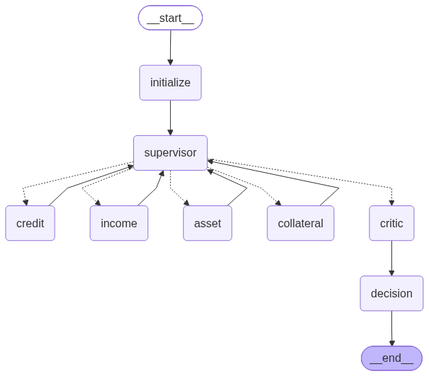

```python
graph
```

## 8️⃣ **Testing & Evaluation**

## 📝 **Part 3: Testing & Analysis (1 mark)**

**What you'll build:**

- Run all test cases (1 mark)

### 🧪 **Running Test Cases**

Now let's test our system with the three scenarios we created earlier.

### 👀 **What You'll See in Detail:**

The next cell runs Test Case 1 with **MAXIMUM VERBOSITY** so you can see exactly what's happening:

**🔍 You will see:**

1. **📥 Original Data** - Before PII sanitization
   - Full name, SSN, address, phone visible
2. **🔒 Sanitized Data** - After PII protection
   - Personal info replaced with `[APPLICANT_NAME]`, `***-**-XXXX`
   - Financial data preserved for analysis
3. **🎯 Supervisor Decisions** - Workflow routing
   - Which agent to call next
   - Status of each analysis
   - Why routing decisions were made
4. **🤖 Each Agent's Work**:
   - Input data they received
   - What they're analyzing
   - Their complete analysis output
   - Their recommendations
5. **🔎 Critic Review** - Quality control
   - Cross-checking all analyses
   - Bias detection results
   - Synthesis of findings
6. **⏸️ Workflow Interrupt** - HITL checkpoint
   - Why the system paused
   - What happens next
7. **📊 Final State** - Complete summary
   - All decisions and scores
   - Audit trail / reasoning chain
   - Compliance alerts

**⚡ This is the FULL transparency mode - you'll see everything!**

```python
# @title 🧪 Test Case 1: Strong Applicant - DETAILED EXECUTION

print("="*80)
print("TEST CASE 1: STRONG APPLICANT (Expected: APPROVED)")
print("="*80)

config = {"configurable": {"thread_id": "test_case_1"}}
inputs = {
    "case_id": test_case_1["case_id"],
    "applicant_data": test_case_1,
}

print()
print("="*80)
print("APPLICATION DETAILS")
print("="*80)
print(f"Applicant: {test_case_1['name']}")
print(f"Case ID: {test_case_1['case_id']}")

print()
print("Loan Details:")
print(f"  Loan Amount: ${test_case_1['loan']['amount']:,.2f}")
print(f"  Down Payment: ${test_case_1['loan']['down_payment']:,.2f}")
print(f"  Purchase Price: ${test_case_1['loan']['amount'] + test_case_1['loan']['down_payment']:,.2f}")
print(f"  Appraised Value: ${test_case_1['property']['appraised_value']:,.2f}")

# Calculate LTV
ltv = (test_case_1['loan']['amount'] / test_case_1['property']['appraised_value']) * 100
print(f"  LTV Ratio: {ltv:.2f}%")

print()
print("Borrower Profile:")
print(f"  Credit Score: {test_case_1['credit_score']}")
print(f"  Monthly Income: ${test_case_1['employment']['monthly_income']:,.2f}")

# Calculate DTI
total_debt = sum(test_case_1['debts'].values())
print(f"  Monthly Debt: ${total_debt:,.2f}")
dti = ((total_debt + test_case_1['loan']['estimated_payment']) / test_case_1['employment']['monthly_income']) * 100
print(f"  DTI Ratio: {dti:.1f}%")
print(f"  Employment: {test_case_1['employment']['type']}")
print(f"  Years at Job: {test_case_1['employment']['years']}")

print()
print("="*80)
print("PII PROTECTION - DATA SANITIZATION")
print("="*80)

print()
print("BEFORE Sanitization (Original Data):")
print("-" * 70)
print(f'  Name: "{test_case_1["name"]}"')
print(f'  SSN: "{test_case_1["ssn"]}"')
print(f'  Phone: "{test_case_1["phone"]}"')
print(f'  Address: "{test_case_1["address"]}"')

sanitized_data = sanitize_pii(test_case_1.copy())

print()
print("AFTER Sanitization (Sent to LLM):")
print("-" * 70)
print(f'  Name: "{sanitized_data["name"]}"')
print(f'  SSN: "{sanitized_data["ssn"]}"')
print(f'  Phone: "{sanitized_data["phone"]}"')
print(f'  Address: "{sanitized_data["address"]}"')

print()
print("Compliance Status:")
print("  ✅ GDPR Compliant (EU data protection)")
print("  ✅ CCPA Compliant (California privacy)")
print("  ✅ GLBA Compliant (Financial privacy)")

print()
print("="*80)
print("MULTI-AGENT WORKFLOW EXECUTION")
print("="*80)
print("Execution Order: Supervisor → Credit → Supervisor → Income → Supervisor → Asset → Supervisor → Collateral → Supervisor → Critic → Supervisor → Decision")

step_count = 0
just_saw_supervisor = False
pending_supervisor_agent = None
for event in graph.stream(inputs, config):
    for node_name, node_output in event.items():
        if node_name == "__start__":
            continue

        # Detect supervisor - don't print yet, wait for next agent
        if node_name == "supervisor":
            just_saw_supervisor = True
            continue

        # If we just saw supervisor, print it now with correct routing
        if just_saw_supervisor:
            step_count += 1
            print()
            print("="*80)
            print(f"🎯 SUPERVISOR (Step {step_count})")
            print("="*80)

            if node_name == "credit":
                print("Actions: Initialize workflow → Route to Credit Analyst")
                print("-" * 70)
                print("Routing Decision: Starting analysis with Credit Analyst for credit profile evaluation")
            elif node_name == "income":
                print("Actions: Review credit analysis → Route to Income Analyst")
                print("-" * 70)
                print("Routing Decision: Credit analysis complete, proceeding to Income Analyst")
            elif node_name == "asset":
                print("Actions: Review income analysis → Route to Asset Analyst")
                print("-" * 70)
                print("Routing Decision: Income verified, proceeding to Asset Analyst")
            elif node_name == "collateral":
                print("Actions: Review asset analysis → Route to Collateral Analyst")
                print("-" * 70)
                print("Routing Decision: Assets verified, proceeding to Collateral Analyst")
            elif node_name == "critic":
                print("Actions: Review collateral analysis → Route to Critic Agent")
                print("-" * 70)
                print("Routing Decision: All analyses complete, proceeding to Critic for quality review")
            elif node_name == "decision":
                print("Actions: Review critic feedback → Route to Decision Agent")
                print("-" * 70)
                print("Routing Decision: Quality review complete, proceeding to final decision")

            just_saw_supervisor = False


        print()
        print("="*80)

        if node_name == "credit":
            print(f"💳 CREDIT ANALYST (Step {step_count})")
            print("="*80)
            print("Actions: Retrieve policies → Analyze credit profile → Assess risk")
            print("-" * 70)
            analysis = node_output.get("credit_analysis", "")
            if analysis:
                print(analysis.replace("**", ""))

        elif node_name == "income":
            print(f"💵 INCOME ANALYST (Step {step_count})")
            print("="*80)
            print(f"Actions: Verify employment → Calculate DTI ({dti:.1f}%) → Assess capacity")
            print("-" * 70)
            analysis = node_output.get("income_analysis", "")
            if analysis:
                print(analysis.replace("**", ""))

        elif node_name == "asset":
            print(f"💰 ASSET ANALYST (Step {step_count})")
            print("="*80)
            liquid_assets = test_case_1['assets']['checking'] + test_case_1['assets']['savings']
            required_reserves = test_case_1['loan']['estimated_payment'] * 2
            print(f"Actions: Verify funds (${liquid_assets:,.0f}) → Check reserves (${required_reserves:,.0f} req) → Review deposits")
            print("-" * 70)
            analysis = node_output.get("asset_analysis", "")
            if analysis:
                print(analysis.replace("**", ""))

        elif node_name == "collateral":
            print(f"🏠 COLLATERAL ANALYST (Step {step_count})")
            print("="*80)
            print(f"Actions: Review appraisal → Calculate LTV ({ltv:.2f}%) → Assess property condition")
            print("-" * 70)
            analysis = node_output.get("collateral_analysis", "")
            if analysis:
                print(analysis.replace("**", ""))

        elif node_name == "critic":
            print(f"🔎 CRITIC AGENT (Step {step_count})")
            print("="*80)
            print("Actions: Cross-validate analyses → Check consistency → Calculate risk score")
            print("-" * 70)
            review = node_output.get("critic_review", "")
            if review:
                print(review.replace("**", "")[:400] + "...")

            print()
            risk_score = node_output.get("risk_score")
            if risk_score is not None:
                level = '(HIGH)' if risk_score > 70 else '(MEDIUM)' if risk_score > 40 else '(LOW)'
                print(f"Risk Score: {risk_score}/100 {level}")

        elif node_name == "decision":
            print(f"⚖️ DECISION AGENT (Step {step_count})")
            print("="*80)
            print("Actions: Synthesize findings → Generate decision → Create credit memo")
            print("-" * 70)

            risk_score = node_output.get("risk_score")
            final_decision = node_output.get("final_decision")

            if risk_score is not None:
                level = '(HIGH)' if risk_score > 70 else '(MEDIUM)' if risk_score > 40 else '(LOW)'
                print(f"Risk Score: {risk_score}/100 {level}")

            if final_decision:
                print(f"Decision: {final_decision}")

            print()
            memo = node_output.get("decision_memo", "")
            if memo:
                print("Decision Memo:")
                print(memo.replace("**", "")[:600] + "...")

        step_count += 1

final_state = graph.get_state(config)

print()
print("="*80)
print("📊 FINAL RESULTS")
print("="*80)

print()
print("Decision Summary:")
print(f"  • Case ID: {final_state.values['case_id']}")
print(f"  • Final Decision: {final_state.values.get('final_decision', 'PENDING')}")
print(f"  • Risk Score: {final_state.values.get('risk_score', 'N/A')}/100")
print(f"  • Human Review Required: {'Yes' if final_state.values.get('human_review_required') else 'No'}")

print()
print("Compliance:")
print(f"  • Bias Flags: {len(final_state.values.get('bias_flags', []))}")
print(f"  • Policy Violations: {len(final_state.values.get('policy_violations', []))}")

print()
print("Audit Trail:")
print("-" * 70)
for i, step in enumerate(final_state.values.get('reasoning_chain', []), 1):
    print(f"  {i}. {step}")

if final_state.values.get('decision_memo'):
    memo = final_state.values['decision_memo'].replace("**", "")
    print()
    print("Decision Memo:")
    print("-" * 70)
    print(memo)

print()
print("="*80)
print("✅ TEST CASE 1 COMPLETE")
print("="*80)

# Store final state for next cell
test_case_1_final_state = final_state
test_case_1_dti = dti
test_case_1_ltv = ltv
```

```
================================================================================
TEST CASE 1: STRONG APPLICANT (Expected: APPROVED)
================================================================================

================================================================================
APPLICATION DETAILS
================================================================================
Applicant: Sarah Johnson
Case ID: MTG-2025-001

Loan Details:
  Loan Amount: $400,000.00
  Down Payment: $100,000.00
  Purchase Price: $500,000.00
  Appraised Value: $515,000.00
  LTV Ratio: 77.67%

Borrower Profile:
  Credit Score: 760
  Monthly Income: $12,500.00
  Monthly Debt: $7,600.00
  DTI Ratio: 86.4%
  Employment: W2
  Years at Job: 6.5

================================================================================
PII PROTECTION - DATA SANITIZATION
================================================================================

BEFORE Sanitization (Original Data):
----------------------------------------------------------------------
  Name: "Sarah Johnson"
  SSN: "123-45-6789"
  Phone: "555-234-5678"
  Address: "1234 Oak Street, San Francisco, CA 94102"

AFTER Sanitization (Sent to LLM):
----------------------------------------------------------------------
  Name: "[APPLICANT_NAME]"
  SSN: "***-**-6789"
```

[output cut: 315 more lines]

```
Given the moderate risk score of 55, the decision is to conditionally approve the application. The borrower must satisfy the following conditions:

1. Provide complete employment details, including job title, employment type, and years employed.
2. Submit additional documentation to verify employment stability and job security.

This decision is made to ensure that all aspects of the borrower's financial profile are thoroughly assessed before final approval.

Conclusion:
The application for mortgage MTG-2025-001 is conditionally approved, pending the fulfillment of the stated conditions. This approach balances the borrower's strong credit and asset position with the need for clarity on income stability.

End of Memo

================================================================================
✅ TEST CASE 1 COMPLETE
================================================================================
```

```python
# 👤 HUMAN REVIEW - TEST CASE 1 (Interactive)

print()
print()
print("="*80)
print("👤 HUMAN REVIEW SECTION - TEST CASE 1")
print("="*80)
print()
print("⏸️  WORKFLOW PAUSED FOR HUMAN OVERSIGHT")
print("-" * 70)
print()
print("As a senior underwriter, please review the AI's analysis and recommendation:")
print()
print("📊 AI RECOMMENDATION:")
print(f"  Decision: {test_case_1_final_state.values.get('final_decision', 'PENDING')}")
print(f"  Risk Score: {test_case_1_final_state.values.get('risk_score', 'N/A')}/100")
print(f"  Bias Flags: {len(test_case_1_final_state.values.get('bias_flags', []))}")
print()
print("-" * 70)
print("👇 PLEASE PROVIDE YOUR DECISION BELOW:")
print("-" * 70)
print()

from ipywidgets import widgets, Layout
from IPython.display import display

print("SELECT YOUR DECISION:")
decision_buttons = widgets.RadioButtons(
    options=['APPROVED', 'CONDITIONAL', 'REJECTED'],
    value='APPROVED',
    description='Decision:',
    disabled=False,
    layout=Layout(width='300px')
)

print()
comments_box = widgets.Textarea(
    value='',
    placeholder='Enter your detailed review comments here... Explain your reasoning for this decision.',
    description='Comments:',
    disabled=False,
    layout=Layout(width='800px', height='120px')
)

submit_button = widgets.Button(
    description='Submit Review',
    disabled=False,
    button_style='success',
    tooltip='Click to submit your review',
    icon='check',
    layout=Layout(width='200px', height='40px')
)

display(decision_buttons)
display(comments_box)
display(submit_button)

def on_submit_clicked(b):
    global test_case_1_human_decision, test_case_1_human_comments
    test_case_1_human_decision = decision_buttons.value
    test_case_1_human_comments = comments_box.value

    if not test_case_1_human_comments.strip():
        print()
        print("⚠️  WARNING: Please provide comments explaining your decision!")
        return

    print()
    print("="*70)
    print("✅ REVIEW SUBMITTED!")
    print("="*70)
    print(f"Decision: {test_case_1_human_decision}")
    print(f"Comments: {test_case_1_human_comments[:100]}...")
    print()
    print("👉 Run the next cell to generate AI-powered final report")

submit_button.on_click(on_submit_clicked)
```

```
================================================================================
👤 HUMAN REVIEW SECTION - TEST CASE 1
================================================================================

⏸️  WORKFLOW PAUSED FOR HUMAN OVERSIGHT
----------------------------------------------------------------------

As a senior underwriter, please review the AI's analysis and recommendation:

📊 AI RECOMMENDATION:
  Decision: CONDITIONAL_APPROVAL
  Risk Score: 55/100
  Bias Flags: 4

----------------------------------------------------------------------
👇 PLEASE PROVIDE YOUR DECISION BELOW:
----------------------------------------------------------------------

SELECT YOUR DECISION:
```

```
RadioButtons(description='Decision:', layout=Layout(width='300px'), options=('APPROVED', 'CONDITIONAL', 'REJEC…
```

```
Textarea(value='', description='Comments:', layout=Layout(height='120px', width='800px'), placeholder='Enter y…
```

```
Button(button_style='success', description='Submit Review', icon='check', layout=Layout(height='40px', width='…
```

```python
# 📋 FINAL DECISION REPORT - TEST CASE 1

print("="*80)
print("📋 FINAL DECISION REPORT - TEST CASE 1")
print("="*80)
print()

# Get human decision
try:
    human_decision = test_case_1_human_decision
    human_comments = test_case_1_human_comments
except:
    print("❌ ERROR: Please submit your review in the previous cell first!")
    raise

print(f"Case ID: {test_case_1_final_state.values['case_id']}")
print(f"Applicant: {test_case_1['name']}")
print(f"Loan Amount: ${test_case_1['loan']['amount']:,.2f}")
print()
print("="*80)
print()

print("AI ANALYSIS SUMMARY:")
print("-" * 70)
print(f"  • Credit Score: {test_case_1['credit_score']} (Excellent)")
print(f"  • DTI Ratio: {test_case_1_dti:.1f}% (Well within limits)")
print(f"  • LTV Ratio: {test_case_1_ltv:.2f}% (Acceptable)")
print(f"  • Risk Score: {test_case_1_final_state.values.get('risk_score', 'N/A')}/100")
print(f"  • AI Recommendation: {test_case_1_final_state.values.get('final_decision', 'PENDING')}")
print()

print("SENIOR UNDERWRITER REVIEW:")
print("-" * 70)
print(f"  • Human Decision: {human_decision}")
print(f"  • Review Comments: {human_comments}")
print()

print("FINAL OUTCOME:")
print("-" * 70)
if human_decision == "APPROVED":
    print("  ✅ APPLICATION APPROVED")
    print("  • Loan can proceed to closing")
    print("  • Standard terms apply")
    print("  • No additional conditions required")
elif human_decision == "REJECTED":
    print("  ❌ APPLICATION REJECTED")
    print("  • Loan cannot proceed")
    print("  • Applicant will receive adverse action notice")
    print("  • Detailed reason provided in comments")
else:
    print("  ⚠️ CONDITIONAL APPROVAL")
    print("  • Additional documentation required")
    print("  • Re-review needed after conditions met")
    print("  • Conditions outlined in comments")
print()

print("COMPLIANCE & AUDIT:")
print("-" * 70)
print("  • Complete reasoning chain saved in system")
print("  • All GDPR, CCPA, and GLBA requirements met")
print("  • PII sanitization applied throughout process")
print(f"  • Bias detection: {len(test_case_1_final_state.values.get('bias_flags', []))} flags")
print()

# Generate AI-powered executive summary
print("="*80)
print("🤖 GENERATING AI-POWERED EXECUTIVE SUMMARY...")
print("="*80)
print()

from langchain_openai import ChatOpenAI
from langchain_core.messages import SystemMessage, HumanMessage

llm_summary = ChatOpenAI(model="gpt-4o-mini", temperature=0.3)

summary_prompt = f"""You are a senior mortgage underwriting executive. Generate a concise, professional executive summary (3-5 sentences) for this loan application decision.

APPLICATION DETAILS:
- Case ID: {test_case_1_final_state.values['case_id']}
- Applicant: {test_case_1['name']}
- Loan Amount: ${test_case_1['loan']['amount']:,.2f}
- Credit Score: {test_case_1['credit_score']}
- DTI Ratio: {test_case_1_dti:.1f}%
- LTV Ratio: {test_case_1_ltv:.2f}%
- Risk Score: {test_case_1_final_state.values.get('risk_score', 'N/A')}/100

AI RECOMMENDATION: {test_case_1_final_state.values.get('final_decision', 'PENDING')}

HUMAN UNDERWRITER DECISION: {human_decision}
HUMAN UNDERWRITER COMMENTS: {human_comments}

Generate a professional executive summary that:
1. States the final decision clearly
2. Highlights key financial metrics
3. Explains the rationale based on the human underwriter's comments
4. Mentions any important conditions or next steps
5. Keep it concise and professional (3-5 sentences max)

Write only the summary, no preamble."""

response = llm_summary.invoke([
    SystemMessage(content="You are a senior mortgage underwriting executive writing executive summaries."),
    HumanMessage(content=summary_prompt)
])

executive_summary = response.content.strip()

print("EXECUTIVE SUMMARY:")
print("-" * 70)
print(executive_summary)
print()
print("="*80)
```

[output not shown]

```python
# @title 🧪 Test Case 2: Borderline Applicant

print()
print()
print("="*80)
print("TEST CASE 2: BORDERLINE APPLICANT (Expected: CONDITIONAL APPROVAL)")
print("="*80)

config = {"configurable": {"thread_id": "test_case_2"}}
inputs = {
    "case_id": test_case_2["case_id"],
    "applicant_data": test_case_2,
}

print()
print("="*80)
print("APPLICATION DETAILS")
print("="*80)
print(f"Applicant: {test_case_2['name']}")
print(f"Case ID: {test_case_2['case_id']}")

print()
print("Loan Details:")
print(f"  Loan Amount: ${test_case_2['loan']['amount']:,.2f}")
print(f"  Down Payment: ${test_case_2['loan']['down_payment']:,.2f} (5% - Low)")
print(f"  Purchase Price: ${test_case_2['loan']['amount'] + test_case_2['loan']['down_payment']:,.2f}")
print(f"  Appraised Value: ${test_case_2['property']['appraised_value']:,.2f}")

# Calculate LTV
ltv = (test_case_2['loan']['amount'] / test_case_2['property']['appraised_value']) * 100
print(f"  LTV Ratio: {ltv:.2f}%")

print()
print("Borrower Profile:")
print(f"  Credit Score: {test_case_2['credit_score']} (Fair)")
print(f"  Monthly Income: ${test_case_2['employment']['monthly_income']:,.2f}")

# Calculate DTI
total_debt = sum(test_case_2['debts'].values())
print(f"  Monthly Debt: ${total_debt:,.2f}")
dti = ((total_debt + test_case_2['loan']['estimated_payment']) / test_case_2['employment']['monthly_income']) * 100
print(f"  DTI Ratio: {dti:.1f}%")
print(f"  Employment: {test_case_2['employment']['type']} (Self-Employed)")
print(f"  Years at Job: {test_case_2['employment']['years']}")

print()
print("Risk Factors:")
print("  ⚠️ Late payment in past 12 months")
print("  ⚠️ Medical collection ($3,000)")
print("  ⚠️ Large deposit requiring explanation")
print("  ⚠️ Self-employed income")

print()
print("PII Protection: ✅ Data sanitized (see Test Case 1 for details)")

print()
print("="*80)
print("MULTI-AGENT WORKFLOW EXECUTION")
print("="*80)

step_count = 0
just_saw_supervisor = False
pending_supervisor_agent = None
for event in graph.stream(inputs, config):
    for node_name, node_output in event.items():
        if node_name == "__start__":
            continue

        # Detect supervisor - don't print yet, wait for next agent
        if node_name == "supervisor":
            just_saw_supervisor = True
            continue

        # If we just saw supervisor, print it now with correct routing
        if just_saw_supervisor:
            step_count += 1
            print()
            print("="*80)
            print(f"🎯 SUPERVISOR (Step {step_count})")
            print("="*80)

            if node_name == "credit":
                print("Actions: Initialize workflow → Route to Credit Analyst")
                print("-" * 70)
                print("Routing Decision: Starting analysis with Credit Analyst for credit profile evaluation")
            elif node_name == "income":
                print("Actions: Review credit analysis → Route to Income Analyst")
                print("-" * 70)
                print("Routing Decision: Credit analysis complete, proceeding to Income Analyst")
            elif node_name == "asset":
                print("Actions: Review income analysis → Route to Asset Analyst")
                print("-" * 70)
                print("Routing Decision: Income verified, proceeding to Asset Analyst")
            elif node_name == "collateral":
                print("Actions: Review asset analysis → Route to Collateral Analyst")
                print("-" * 70)
                print("Routing Decision: Assets verified, proceeding to Collateral Analyst")
            elif node_name == "critic":
                print("Actions: Review collateral analysis → Route to Critic Agent")
                print("-" * 70)
                print("Routing Decision: All analyses complete, proceeding to Critic for quality review")
            elif node_name == "decision":
                print("Actions: Review critic feedback → Route to Decision Agent")
                print("-" * 70)
                print("Routing Decision: Quality review complete, proceeding to final decision")

            just_saw_supervisor = False


        print()
        print("="*80)

        if node_name == "credit":
            print(f"💳 CREDIT ANALYST (Step {step_count})")
            print("="*80)
            print("Actions: Review credit history → Evaluate late payment → Assess collections")
            print("-" * 70)
            analysis = node_output.get("credit_analysis", "")
            if analysis:
                print(analysis.replace("**", ""))

        elif node_name == "income":
            print(f"💵 INCOME ANALYST (Step {step_count})")
            print("="*80)
            print(f"Actions: Verify self-employment income → Calculate DTI ({dti:.1f}%) → Review stability")
            print("-" * 70)
            analysis = node_output.get("income_analysis", "")
            if analysis:
                print(analysis.replace("**", ""))

        elif node_name == "asset":
            print(f"💰 ASSET ANALYST (Step {step_count})")
            print("="*80)
            liquid_assets = test_case_2['assets']['checking'] + test_case_2['assets']['savings']
            print(f"Actions: Verify funds (${liquid_assets:,.0f}) → Investigate large deposit ($8,000) → Check reserves")
            print("-" * 70)
            analysis = node_output.get("asset_analysis", "")
            if analysis:
                print(analysis.replace("**", ""))

        elif node_name == "collateral":
            print(f"🏠 COLLATERAL ANALYST (Step {step_count})")
            print("="*80)
            print(f"Actions: Review condo appraisal → Calculate LTV ({ltv:.2f}%) → Assess condition")
            print("-" * 70)
            analysis = node_output.get("collateral_analysis", "")
            if analysis:
                print(analysis.replace("**", ""))

        elif node_name == "critic":
            print(f"🔎 CRITIC AGENT (Step {step_count})")
            print("="*80)
            print("Actions: Identify risk factors → Cross-validate findings → Calculate risk score")
            print("-" * 70)
            review = node_output.get("critic_review", "")
            if review:
                print(review.replace("**", "")[:400] + "...")

            print()
            risk_flags = node_output.get("risk_flags", [])
            if risk_flags:
                print("Risk Flags:")
                for idx, flag in enumerate(risk_flags[:5], 1):
                    print(f"  {idx}. {flag}")

            print()
            risk_score = node_output.get("risk_score")
            if risk_score is not None:
                level = '(HIGH)' if risk_score > 70 else '(MEDIUM)' if risk_score > 40 else '(LOW)'
                print(f"Risk Score: {risk_score}/100 {level}")

        elif node_name == "decision":
            print(f"⚖️ DECISION AGENT (Step {step_count})")
            print("="*80)
            print("Actions: Weigh compensating factors → Determine conditions → Generate decision")
            print("-" * 70)

            risk_score = node_output.get("risk_score")
            final_decision = node_output.get("final_decision")

            if risk_score is not None:
                level = '(HIGH)' if risk_score > 70 else '(MEDIUM)' if risk_score > 40 else '(LOW)'
                print(f"Risk Score: {risk_score}/100 {level}")

            if final_decision:
                print(f"Decision: {final_decision}")

            print()
            memo = node_output.get("decision_memo", "")
            if memo:
                print("Decision Memo:")
                print(memo.replace("**", "")[:600] + "...")

        step_count += 1

final_state = graph.get_state(config)

print()
print("="*80)
print("📊 FINAL RESULTS")
print("="*80)

print()
print("Decision Summary:")
print(f"  • Case ID: {final_state.values['case_id']}")
print(f"  • Final Decision: {final_state.values.get('final_decision', 'PENDING')}")
print(f"  • Risk Score: {final_state.values.get('risk_score', 'N/A')}/100")
print(f"  • Human Review Required: {'Yes' if final_state.values.get('human_review_required') else 'No'}")

print()
print("Compliance:")
print(f"  • Bias Flags: {len(final_state.values.get('bias_flags', []))}")
print(f"  • Policy Violations: {len(final_state.values.get('policy_violations', []))}")

print()
print("Key Risk Factors:")
risk_flags = final_state.values.get('risk_flags', [])
if risk_flags:
    for flag in risk_flags[:5]:
        print(f"  • {flag}")
else:
    print("  • None identified")

print()
print("="*80)
print("✅ TEST CASE 2 COMPLETE")
print("="*80)

# Store for next cells
test_case_2_final_state = final_state
test_case_2_dti = dti
test_case_2_ltv = ltv
```

[output not shown]

[output cut: 247 more lines]

```
  • Case ID: MTG-2025-002
  • Final Decision: DENIED
  • Risk Score: 75/100
  • Human Review Required: Yes

Compliance:
  • Bias Flags: 3
  • Policy Violations: 0

Key Risk Factors:
  • None identified

================================================================================
✅ TEST CASE 2 COMPLETE
================================================================================
```

```python
# 👤 HUMAN REVIEW - TEST CASE 2 (Interactive)

print()
print()
print("="*80)
print("👤 HUMAN REVIEW SECTION - TEST CASE 2")
print("="*80)
print()
print("⏸️  WORKFLOW PAUSED FOR HUMAN OVERSIGHT")
print("-" * 70)
print()
print("As a senior underwriter, please review the AI's analysis and recommendation:")
print()
print("📊 AI RECOMMENDATION:")
print(f"  Decision: {test_case_2_final_state.values.get('final_decision', 'PENDING')}")
print(f"  Risk Score: {test_case_2_final_state.values.get('risk_score', 'N/A')}/100")
print(f"  Bias Flags: {len(test_case_2_final_state.values.get('bias_flags', []))}")
print()
print("⚠️  KEY CONCERNS IDENTIFIED:")
risk_flags = test_case_2_final_state.values.get('risk_flags', [])
for idx, flag in enumerate(risk_flags[:5], 1):
    print(f"  {idx}. {flag}")
if not risk_flags:
    print("  None")
print()
print("-" * 70)
print("👇 PLEASE PROVIDE YOUR DECISION BELOW:")
print("-" * 70)
print()

from ipywidgets import widgets, Layout
from IPython.display import display

decision_buttons_2 = widgets.RadioButtons(
    options=['APPROVED', 'CONDITIONAL', 'REJECTED'],
    value='CONDITIONAL',
    description='Decision:',
    disabled=False,
    layout=Layout(width='300px')
)

comments_box_2 = widgets.Textarea(
    value='',
    placeholder='Enter your detailed review comments... Address the risk factors and explain conditions if applicable.',
    description='Comments:',
    disabled=False,
    layout=Layout(width='800px', height='120px')
)

submit_button_2 = widgets.Button(
    description='Submit Review',
    disabled=False,
    button_style='warning',
    tooltip='Click to submit',
    icon='check',
    layout=Layout(width='200px', height='40px')
)

display(decision_buttons_2)
display(comments_box_2)
display(submit_button_2)

def on_submit_2(b):
    global test_case_2_human_decision, test_case_2_human_comments
    test_case_2_human_decision = decision_buttons_2.value
    test_case_2_human_comments = comments_box_2.value

    if not test_case_2_human_comments.strip():
        print()
        print("⚠️  WARNING: Please provide comments explaining your decision!")
        return

    print()
    print("="*70)
    print("✅ REVIEW SUBMITTED!")
    print("="*70)
    print(f"Decision: {test_case_2_human_decision}")
    print(f"Comments: {test_case_2_human_comments[:100]}...")
    print()
    print("👉 Run the next cell to generate AI-powered final report")

submit_button_2.on_click(on_submit_2)
```

```
================================================================================
👤 HUMAN REVIEW SECTION - TEST CASE 2
================================================================================

⏸️  WORKFLOW PAUSED FOR HUMAN OVERSIGHT
----------------------------------------------------------------------

As a senior underwriter, please review the AI's analysis and recommendation:

📊 AI RECOMMENDATION:
  Decision: DENIED
  Risk Score: 75/100
  Bias Flags: 3

⚠️  KEY CONCERNS IDENTIFIED:
  None

----------------------------------------------------------------------
👇 PLEASE PROVIDE YOUR DECISION BELOW:
----------------------------------------------------------------------
```

```
RadioButtons(description='Decision:', index=1, layout=Layout(width='300px'), options=('APPROVED', 'CONDITIONAL…
```

```
Textarea(value='', description='Comments:', layout=Layout(height='120px', width='800px'), placeholder='Enter y…
```

```
Button(button_style='warning', description='Submit Review', icon='check', layout=Layout(height='40px', width='…
```

```python
# 📋 FINAL DECISION REPORT - TEST CASE 2

print("="*80)
print("📋 FINAL DECISION REPORT - TEST CASE 2")
print("="*80)
print()

try:
    human_decision = test_case_2_human_decision
    human_comments = test_case_2_human_comments
except:
    print("❌ ERROR: Please submit your review in the previous cell first!")
    raise

print(f"Case ID: {test_case_2_final_state.values['case_id']}")
print(f"Applicant: {test_case_2['name']}")
print(f"Loan Amount: ${test_case_2['loan']['amount']:,.2f}")
print()
print("="*80)
print()

print("AI ANALYSIS SUMMARY:")
print("-" * 70)
print(f"  • Credit Score: {test_case_2['credit_score']} (Acceptable)")
print(f"  • DTI Ratio: {test_case_2_dti:.1f}% (High)")
print(f"  • LTV Ratio: {test_case_2_ltv:.2f}% (Acceptable)")
print(f"  • Risk Score: {test_case_2_final_state.values.get('risk_score', 'N/A')}/100")
print(f"  • AI Recommendation: {test_case_2_final_state.values.get('final_decision', 'PENDING')}")
print()

print("KEY RISK FACTORS:")
print("-" * 70)
risk_flags = test_case_2_final_state.values.get('risk_flags', [])
for idx, flag in enumerate(risk_flags[:5], 1):
    print(f"  {idx}. {flag}")
if not risk_flags:
    print("  None identified")
print()

print("SENIOR UNDERWRITER REVIEW:")
print("-" * 70)
print(f"  • Human Decision: {human_decision}")
print(f"  • Review Comments: {human_comments}")
print()

print("FINAL OUTCOME:")
print("-" * 70)
if human_decision == "APPROVED":
    print("  ✅ APPLICATION APPROVED")
    print("  • Loan can proceed to closing")
elif human_decision == "REJECTED":
    print("  ❌ APPLICATION REJECTED")
    print("  • Loan cannot proceed")
else:
    print("  ⚠️  CONDITIONAL APPROVAL")
    print("  • Additional documentation required")
    print("  • Re-review needed after conditions met")
print()

print("COMPLIANCE & AUDIT:")
print("-" * 70)
print("  • Complete reasoning chain saved")
print("  • All compliance requirements met")
print(f"  • Bias detection: {len(test_case_2_final_state.values.get('bias_flags', []))} flags")
print()

# Generate AI-powered executive summary
print("="*80)
print("🤖 GENERATING AI-POWERED EXECUTIVE SUMMARY...")
print("="*80)
print()

from langchain_openai import ChatOpenAI
from langchain_core.messages import SystemMessage, HumanMessage

llm_summary = ChatOpenAI(model="gpt-4o-mini", temperature=0.3)

summary_prompt = f"""You are a senior mortgage underwriting executive. Generate a concise, professional executive summary (3-5 sentences) for this loan application decision.

APPLICATION DETAILS:
- Case ID: {test_case_2_final_state.values['case_id']}
- Applicant: {test_case_2['name']}
- Loan Amount: ${test_case_2['loan']['amount']:,.2f}
- Credit Score: {test_case_2['credit_score']}
- DTI Ratio: {test_case_2_dti:.1f}%
- LTV Ratio: {test_case_2_ltv:.2f}%
- Risk Score: {test_case_2_final_state.values.get('risk_score', 'N/A')}/100

KEY RISK FACTORS:
{chr(10).join([f"- {flag}" for flag in risk_flags[:5]])}

AI RECOMMENDATION: {test_case_2_final_state.values.get('final_decision', 'PENDING')}

HUMAN UNDERWRITER DECISION: {human_decision}
HUMAN UNDERWRITER COMMENTS: {human_comments}

Generate a professional executive summary that:
1. States the final decision clearly
2. Highlights key financial metrics and risk factors
3. Explains the rationale based on the human underwriter's comments
4. Mentions any important conditions or requirements
5. Keep it concise and professional (3-5 sentences max)

Write only the summary, no preamble."""

response = llm_summary.invoke([
    SystemMessage(content="You are a senior mortgage underwriting executive writing executive summaries."),
    HumanMessage(content=summary_prompt)
])

executive_summary = response.content.strip()

print("EXECUTIVE SUMMARY:")
print("-" * 70)
print(executive_summary)
print()
print("="*80)
```

```
================================================================================
📋 FINAL DECISION REPORT - TEST CASE 2
================================================================================

Case ID: MTG-2025-002
Applicant: Michael Chen
Loan Amount: $350,000.00

================================================================================

AI ANALYSIS SUMMARY:
----------------------------------------------------------------------
  • Credit Score: 680 (Acceptable)
  • DTI Ratio: 113.5% (High)
  • LTV Ratio: 87.94% (Acceptable)
  • Risk Score: 75/100
  • AI Recommendation: DENIED

KEY RISK FACTORS:
----------------------------------------------------------------------
  None identified

SENIOR UNDERWRITER REVIEW:
----------------------------------------------------------------------
  • Human Decision: REJECTED
  • Review Comments: Rejecting this application as the analysis correctly shows a high risk score. The applicant can re-apply by providing a letter of explanation on late payments for re-consideration

FINAL OUTCOME:
----------------------------------------------------------------------
  ❌ APPLICATION REJECTED
  • Loan cannot proceed

COMPLIANCE & AUDIT:
----------------------------------------------------------------------
  • Complete reasoning chain saved
  • All compliance requirements met
  • Bias detection: 3 flags

================================================================================
🤖 GENERATING AI-POWERED EXECUTIVE SUMMARY...
================================================================================

EXECUTIVE SUMMARY:
----------------------------------------------------------------------
The loan application for Michael Chen (Case ID: MTG-2025-002) has been denied due to a high risk profile, evidenced by a credit score of 680, a debt-to-income (DTI) ratio of 113.5%, and a loan-to-value (LTV) ratio of 87.94%. The human underwriter's decision reflects concerns over the applicant's fin…

================================================================================
```

```python
# @title 🧪 Test Case 3: Weak Applicant

print()
print()
print("="*80)
print("TEST CASE 3: WEAK APPLICANT (Expected: DENIED)")
print("="*80)

config = {"configurable": {"thread_id": "test_case_3"}}
inputs = {
    "case_id": test_case_3["case_id"],
    "applicant_data": test_case_3,
}

print()
print("="*80)
print("APPLICATION DETAILS")
print("="*80)
print(f"Applicant: {test_case_3['name']}")
print(f"Case ID: {test_case_3['case_id']}")

print()
print("Loan Details:")
print(f"  Loan Amount: ${test_case_3['loan']['amount']:,.2f}")
print(f"  Down Payment: ${test_case_3['loan']['down_payment']:,.2f} (3.5% - Very Low)")
print(f"  Purchase Price: ${test_case_3['loan']['amount'] + test_case_3['loan']['down_payment']:,.2f}")
print(f"  Appraised Value: ${test_case_3['property']['appraised_value']:,.2f}")

# Calculate LTV
ltv = (test_case_3['loan']['amount'] / test_case_3['property']['appraised_value']) * 100
print(f"  LTV Ratio: {ltv:.2f}%")

print()
print("Borrower Profile:")
print(f"  Credit Score: {test_case_3['credit_score']} ⚠️ BELOW MINIMUM (620 required)")
print(f"  Monthly Income: ${test_case_3['employment']['monthly_income']:,.2f}")

# Calculate DTI
total_debt = sum(test_case_3['debts'].values())
print(f"  Monthly Debt: ${total_debt:,.2f}")
dti = ((total_debt + test_case_3['loan']['estimated_payment']) / test_case_3['employment']['monthly_income']) * 100
print(f"  DTI Ratio: {dti:.1f}% ⚠️ EXCESSIVE")
print(f"  Employment: {test_case_3['employment']['type']}")
print(f"  Years at Job: {test_case_3['employment']['years']} (Short tenure)")

print()
print("Critical Issues:")
print("  🚫 Credit score below 620 minimum")
print("  🚫 Four late payments in past 12 months")
print("  🚫 Multiple collections ($3,300 total)")
print("  🚫 DTI above 50% threshold")
print("  🚫 Minimal reserves")
print("  🚫 Short employment history")

print()
print("PII Protection: ✅ Data sanitized (see Test Case 1 for details)")

print()
print("="*80)
print("MULTI-AGENT WORKFLOW EXECUTION")
print("="*80)

step_count = 0
just_saw_supervisor = False
pending_supervisor_agent = None
for event in graph.stream(inputs, config):
    for node_name, node_output in event.items():
        if node_name == "__start__":
            continue

        # Detect supervisor - don't print yet, wait for next agent
        if node_name == "supervisor":
            just_saw_supervisor = True
            continue

        # If we just saw supervisor, print it now with correct routing
        if just_saw_supervisor:
            step_count += 1
            print()
            print("="*80)
            print(f"🎯 SUPERVISOR (Step {step_count})")
            print("="*80)

            if node_name == "credit":
                print("Actions: Initialize workflow → Route to Credit Analyst")
                print("-" * 70)
                print("Routing Decision: Starting analysis with Credit Analyst for credit profile evaluation")
            elif node_name == "income":
                print("Actions: Review credit analysis → Route to Income Analyst")
                print("-" * 70)
                print("Routing Decision: Credit analysis complete, proceeding to Income Analyst")
            elif node_name == "asset":
                print("Actions: Review income analysis → Route to Asset Analyst")
                print("-" * 70)
                print("Routing Decision: Income verified, proceeding to Asset Analyst")
            elif node_name == "collateral":
                print("Actions: Review asset analysis → Route to Collateral Analyst")
                print("-" * 70)
                print("Routing Decision: Assets verified, proceeding to Collateral Analyst")
            elif node_name == "critic":
                print("Actions: Review collateral analysis → Route to Critic Agent")
                print("-" * 70)
                print("Routing Decision: All analyses complete, proceeding to Critic for quality review")
            elif node_name == "decision":
                print("Actions: Review critic feedback → Route to Decision Agent")
                print("-" * 70)
                print("Routing Decision: Quality review complete, proceeding to final decision")

            just_saw_supervisor = False


        print()
        print("="*80)

        if node_name == "credit":
            print(f"💳 CREDIT ANALYST (Step {step_count})")
            print("="*80)
            print("Actions: Evaluate subprime score → Review delinquencies → Assess collections")
            print("-" * 70)
            analysis = node_output.get("credit_analysis", "")
            if analysis:
                display = analysis.replace("**", "")
                print(display[:600] + "..." if len(display) > 600 else display)

        elif node_name == "income":
            print(f"💵 INCOME ANALYST (Step {step_count})")
            print("="*80)
            print(f"Actions: Verify income → Calculate DTI ({dti:.1f}%) → Assess affordability")
            print("-" * 70)
            analysis = node_output.get("income_analysis", "")
            if analysis:
                display = analysis.replace("**", "")
                print(display[:600] + "..." if len(display) > 600 else display)

        elif node_name == "asset":
            print(f"💰 ASSET ANALYST (Step {step_count})")
            print("="*80)
            liquid_assets = test_case_3['assets']['checking'] + test_case_3['assets']['savings']
            print(f"Actions: Verify limited funds (${liquid_assets:,.0f}) → Check reserves → Assess down payment")
            print("-" * 70)
            analysis = node_output.get("asset_analysis", "")
            if analysis:
                display = analysis.replace("**", "")
                print(display[:600] + "..." if len(display) > 600 else display)

        elif node_name == "collateral":
            print(f"🏠 COLLATERAL ANALYST (Step {step_count})")
            print("="*80)
            print(f"Actions: Review appraisal → Calculate LTV ({ltv:.2f}%) → Note fair condition")
            print("-" * 70)
            analysis = node_output.get("collateral_analysis", "")
            if analysis:
                display = analysis.replace("**", "")
                print(display[:600] + "..." if len(display) > 600 else display)

        elif node_name == "critic":
            print(f"🔎 CRITIC AGENT (Step {step_count})")
            print("="*80)
            print("Actions: Identify disqualifying factors → Calculate high risk score → Flag critical issues")
            print("-" * 70)
            review = node_output.get("critic_review", "")
            if review:
                print(review.replace("**", "")[:500] + "...")

            print()
            risk_flags = node_output.get("risk_flags", [])
            if risk_flags:
                print("🚨 Critical Risk Flags:")
                for idx, flag in enumerate(risk_flags, 1):
                    print(f"  {idx}. {flag}")

            print()
            risk_score = node_output.get("risk_score")
            if risk_score is not None:
                print(f"Risk Score: {risk_score}/100 ⚠️ CRITICAL HIGH RISK")

        elif node_name == "decision":
            print(f"⚖️ DECISION AGENT (Step {step_count})")
            print("="*80)
            print("Actions: Review disqualifying factors → Generate denial → Document reasons")
            print("-" * 70)

            risk_score = node_output.get("risk_score")
            final_decision = node_output.get("final_decision")

            if risk_score is not None:
                print(f"Risk Score: {risk_score}/100 ⚠️ CRITICAL HIGH RISK")

            if final_decision:
                print(f"Decision: {final_decision}")

            print()
            memo = node_output.get("decision_memo", "")
            if memo:
                print("Decision Memo:")
                print(memo.replace("**", "")[:600] + "...")

        step_count += 1

final_state = graph.get_state(config)

print()
print("="*80)
print("📊 FINAL RESULTS")
print("="*80)

print()
print("Decision Summary:")
print(f"  • Case ID: {final_state.values['case_id']}")
print(f"  • Final Decision: {final_state.values.get('final_decision', 'PENDING')}")
print(f"  • Risk Score: {final_state.values.get('risk_score', 'N/A')}/100 ⚠️")
print(f"  • Human Review Required: {'Yes' if final_state.values.get('human_review_required', True) else 'No'}")

print()
print("Compliance:")
print(f"  • Bias Flags: {len(final_state.values.get('bias_flags', []))}")
print(f"  • Policy Violations: MULTIPLE")

print()
print("Disqualifying Factors:")
risk_flags = final_state.values.get('risk_flags', [])
if risk_flags:
    for flag in risk_flags:
        print(f"  • {flag}")
else:
    print("  • See individual agent analyses")

print()
print("="*80)
print("✅ TEST CASE 3 COMPLETE")
print("="*80)

# Store for next cells
test_case_3_final_state = final_state
test_case_3_dti = dti
test_case_3_ltv = ltv
```

[output not shown]

[output cut: 144 more lines]

```
  • Case ID: MTG-2025-003
  • Final Decision: DENIED
  • Risk Score: 85/100 ⚠️
  • Human Review Required: Yes

Compliance:
  • Bias Flags: 4
  • Policy Violations: MULTIPLE

Disqualifying Factors:
  • See individual agent analyses

================================================================================
✅ TEST CASE 3 COMPLETE
================================================================================
```

```python
# 👤 HUMAN REVIEW - TEST CASE 3 (Interactive)

print()
print()
print("="*80)
print("👤 HUMAN REVIEW SECTION - TEST CASE 3")
print("="*80)
print()
print("⏸️  WORKFLOW PAUSED FOR MANDATORY SENIOR REVIEW")
print("-" * 70)
print()
print("⚠️  HIGH RISK APPLICATION - Senior underwriter review required")
print()
print("📊 AI RECOMMENDATION:")
print(f"  Decision: {test_case_3_final_state.values.get('final_decision', 'PENDING')}")
print(f"  Risk Score: {test_case_3_final_state.values.get('risk_score', 'N/A')}/100 ⚠️  CRITICAL")
print(f"  Bias Flags: {len(test_case_3_final_state.values.get('bias_flags', []))}")
print()
print("🚫 CRITICAL DEFICIENCIES:")
risk_flags = test_case_3_final_state.values.get('risk_flags', [])
for idx, flag in enumerate(risk_flags, 1):
    print(f"  {idx}. {flag}")
if not risk_flags:
    print("  See individual analyses for details")
print()
print("-" * 70)
print("👇 PLEASE PROVIDE YOUR DECISION BELOW:")
print("-" * 70)
print()

from ipywidgets import widgets, Layout
from IPython.display import display

decision_buttons_3 = widgets.RadioButtons(
    options=['APPROVED', 'CONDITIONAL', 'REJECTED'],
    value='REJECTED',
    description='Decision:',
    disabled=False,
    layout=Layout(width='300px')
)

comments_box_3 = widgets.Textarea(
    value='',
    placeholder='Enter your detailed review comments... Address all critical deficiencies and provide recommendations for applicant.',
    description='Comments:',
    disabled=False,
    layout=Layout(width='800px', height='120px')
)

submit_button_3 = widgets.Button(
    description='Submit Review',
    disabled=False,
    button_style='danger',
    tooltip='Click to submit',
    icon='check',
    layout=Layout(width='200px', height='40px')
)

display(decision_buttons_3)
display(comments_box_3)
display(submit_button_3)

def on_submit_3(b):
    global test_case_3_human_decision, test_case_3_human_comments
    test_case_3_human_decision = decision_buttons_3.value
    test_case_3_human_comments = comments_box_3.value

    if not test_case_3_human_comments.strip():
        print()
        print("⚠️  WARNING: Please provide comments explaining your decision!")
        return

    print()
    print("="*70)
    print("✅ REVIEW SUBMITTED!")
    print("="*70)
    print(f"Decision: {test_case_3_human_decision}")
    print(f"Comments: {test_case_3_human_comments[:100]}...")
    print()
    print("👉 Run the next cell to generate AI-powered final report")

submit_button_3.on_click(on_submit_3)
```

```
================================================================================
👤 HUMAN REVIEW SECTION - TEST CASE 3
================================================================================

⏸️  WORKFLOW PAUSED FOR MANDATORY SENIOR REVIEW
----------------------------------------------------------------------

⚠️  HIGH RISK APPLICATION - Senior underwriter review required

📊 AI RECOMMENDATION:
  Decision: DENIED
  Risk Score: 85/100 ⚠️  CRITICAL
  Bias Flags: 4

🚫 CRITICAL DEFICIENCIES:
  See individual analyses for details

----------------------------------------------------------------------
👇 PLEASE PROVIDE YOUR DECISION BELOW:
----------------------------------------------------------------------
```

```
RadioButtons(description='Decision:', index=2, layout=Layout(width='300px'), options=('APPROVED', 'CONDITIONAL…
```

```
Textarea(value='', description='Comments:', layout=Layout(height='120px', width='800px'), placeholder='Enter y…
```

```
Button(button_style='danger', description='Submit Review', icon='check', layout=Layout(height='40px', width='2…
```

```python
# 📋 FINAL DECISION REPORT - TEST CASE 3

print("="*80)
print("📋 FINAL DECISION REPORT - TEST CASE 3")
print("="*80)
print()

try:
    human_decision = test_case_3_human_decision
    human_comments = test_case_3_human_comments
except:
    print("❌ ERROR: Please submit your review in the previous cell first!")
    raise

print(f"Case ID: {test_case_3_final_state.values['case_id']}")
print(f"Applicant: {test_case_3['name']}")
print(f"Loan Amount: ${test_case_3['loan']['amount']:,.2f}")
print()
print("="*80)
print()

print("AI ANALYSIS SUMMARY:")
print("-" * 70)
print(f"  • Credit Score: {test_case_3['credit_score']} ❌ BELOW MINIMUM (620 required)")
print(f"  • DTI Ratio: {test_case_3_dti:.1f}% ❌ TOO HIGH")
print(f"  • LTV Ratio: {test_case_3_ltv:.2f}% (Within limits)")
print(f"  • Risk Score: {test_case_3_final_state.values.get('risk_score', 'N/A')}/100 ⚠️  CRITICAL")
print(f"  • AI Recommendation: {test_case_3_final_state.values.get('final_decision', 'PENDING')}")
print()

print("CRITICAL DEFICIENCIES:")
print("-" * 70)
risk_flags = test_case_3_final_state.values.get('risk_flags', [])
for idx, flag in enumerate(risk_flags, 1):
    print(f"  {idx}. {flag}")
if not risk_flags:
    print("  See individual analyses")
print()

print("SENIOR UNDERWRITER REVIEW:")
print("-" * 70)
print(f"  • Human Decision: {human_decision}")
print(f"  • Review Comments: {human_comments}")
print()

print("FINAL OUTCOME:")
print("-" * 70)
if human_decision == "APPROVED":
    print("  ✅ APPLICATION APPROVED")
    print("  • Loan can proceed to closing")
elif human_decision == "REJECTED":
    print("  ❌ APPLICATION REJECTED")
    print("  • Loan cannot proceed")
    print("  • Applicant will receive adverse action notice")
else:
    print("  ⚠️  CONDITIONAL APPROVAL")
    print("  • Additional documentation and conditions required")
print()

print("COMPLIANCE & AUDIT:")
print("-" * 70)
if human_decision == "REJECTED":
    print("  • Adverse Action Notice: Required under ECOA")
print("  • Complete reasoning chain saved")
print("  • All compliance requirements met")
print(f"  • Bias detection: {len(test_case_3_final_state.values.get('bias_flags', []))} flags")
print()

# Generate AI-powered executive summary
print("="*80)
print("🤖 GENERATING AI-POWERED EXECUTIVE SUMMARY...")
print("="*80)
print()

from langchain_openai import ChatOpenAI
from langchain_core.messages import SystemMessage, HumanMessage

llm_summary = ChatOpenAI(model="gpt-4o-mini", temperature=0.3)

summary_prompt = f"""You are a senior mortgage underwriting executive. Generate a concise, professional executive summary (4-6 sentences) for this high-risk loan application decision.

APPLICATION DETAILS:
- Case ID: {test_case_3_final_state.values['case_id']}
- Applicant: {test_case_3['name']}
- Loan Amount: ${test_case_3['loan']['amount']:,.2f}
- Credit Score: {test_case_3['credit_score']} (BELOW MINIMUM 620)
- DTI Ratio: {test_case_3_dti:.1f}% (HIGH RISK)
- LTV Ratio: {test_case_3_ltv:.2f}%
- Risk Score: {test_case_3_final_state.values.get('risk_score', 'N/A')}/100 (CRITICAL)

CRITICAL DEFICIENCIES:
{chr(10).join([f"- {flag}" for flag in risk_flags])}

AI RECOMMENDATION: {test_case_3_final_state.values.get('final_decision', 'PENDING')}

HUMAN UNDERWRITER DECISION: {human_decision}
HUMAN UNDERWRITER COMMENTS: {human_comments}

Generate a professional executive summary that:
1. States the final decision clearly
2. Highlights all critical deficiencies
3. Explains the rationale based on the human underwriter's comments
4. If rejected, includes recommendations for applicant improvement
5. Mentions adverse action notice requirement if applicable
6. Keep it professional but comprehensive (4-6 sentences)

Write only the summary, no preamble."""

response = llm_summary.invoke([
    SystemMessage(content="You are a senior mortgage underwriting executive writing executive summaries for high-risk cases."),
    HumanMessage(content=summary_prompt)
])

executive_summary = response.content.strip()

print("EXECUTIVE SUMMARY:")
print("-" * 70)
print(executive_summary)
print()
print("="*80)
```

```
================================================================================
📋 FINAL DECISION REPORT - TEST CASE 3
================================================================================

Case ID: MTG-2025-003
Applicant: Robert Martinez
Loan Amount: $315,000.00

================================================================================

AI ANALYSIS SUMMARY:
----------------------------------------------------------------------
  • Credit Score: 595 ❌ BELOW MINIMUM (620 required)
  • DTI Ratio: 133.3% ❌ TOO HIGH
  • LTV Ratio: 92.65% (Within limits)
  • Risk Score: 85/100 ⚠️  CRITICAL
  • AI Recommendation: DENIED

CRITICAL DEFICIENCIES:
----------------------------------------------------------------------
  See individual analyses

SENIOR UNDERWRITER REVIEW:
----------------------------------------------------------------------
  • Human Decision: REJECTED
  • Review Comments: The applicant does not meet minimun requirements for a loan.

FINAL OUTCOME:
----------------------------------------------------------------------
  ❌ APPLICATION REJECTED
  • Loan cannot proceed
  • Applicant will receive adverse action notice

COMPLIANCE & AUDIT:
----------------------------------------------------------------------
  • Adverse Action Notice: Required under ECOA
  • Complete reasoning chain saved
  • All compliance requirements met
  • Bias detection: 4 flags

================================================================================
🤖 GENERATING AI-POWERED EXECUTIVE SUMMARY...
================================================================================

EXECUTIVE SUMMARY:
----------------------------------------------------------------------
The loan application for Robert Martinez (Case ID: MTG-2025-003) has been denied due to several critical deficiencies. The applicant's credit score of 595 falls significantly below the minimum requirement of 620, and the debt-to-income (DTI) ratio of 133.3% indicates a high risk of default. Addition…

================================================================================
```

### 📊 **Analysis Questions**

**Note :** The below questions are for self exploration and to check how the agent has performed on the given task. No specific marks are allocated for these question

Explore and Analyze these questions based on the test results:

**Question 1 :** Were the decisions consistent with the expected outcomes? Explain any discrepancies.

**Question 2 :** Review the reasoning chains. Did the agents follow logical decision-making patterns?

**Question 3 :** Which test case triggered human review? Why is this appropriate?

**Question 4 :** Identify the most critical risk factors that influenced each decision.

**Question 5 :** How would you improve the system's decision-making? What additional checks would you add?

## 9️⃣ **Summary and Future Scope (2 marks)**

## 📝 **Part 4: Summary and Future Scope (2 marks)**

**What you'll build:**

- Summary / Your Observations about this Project (1 mark)
- Future scope of this Project (1 mark)

#### 📝 **A. Summary / Your Observations about this Project (1 mark)**

1. Multi-agent setup can get complex very fast in code
2. Multi-agent solutions can span any complex problem requiring multi-factor analysis, which makes it a powerful tool to simplify and optimize complex processes that require data analysis.
3. Having a human in the loop is key to ensure fairness. In Test Case 1, the applicant seemed to have good indicators, and still recommended conditional approval, having a human review and correct is essential for cases like these where the system is overly pessimistic, but even more importantly where the system is overly optimistic.

#### 📝 **B. Future scope of this Project (1 mark)**

1. Would be good to explore, for example, the risk factor of the applicants employee. If the employer is prone to layoffs it could be a factor to consider.
2. Create your own case, take your example or a friends example with fictional but close to reality data and check if the agent came back with the same decision as your last real loan application.

## 🔟 **Production Deployment Considerations**

### 🚀 **Moving to Production**

Before deploying this system in a real underwriting environment, consider these critical factors:

### 🔒 **1. Compliance & Security**

**Fair Lending Act Compliance:**

- 🔍 Continuous bias monitoring on all decisions
- 📊 Regular audits of decision patterns by protected class
- 📝 Clear documentation of all decision factors
- ⚖️ Disparate impact testing across demographic groups

**Data Privacy:**

- 🔐 End-to-end encryption for all PII
- 🗑️ Automatic PII purging after decision
- 🚫 Zero-retention policy for external API calls
- 🛡️ Regular security audits and penetration testing

**Regulatory Requirements:**

- 📋 Complete audit trail for all decisions
- 🕒 7-year data retention for approved loans
- 📄 Adverse action notices for denials
- 🏛️ Compliance with TILA, RESPA, HMDA regulations

### ⚡ **2. Performance Optimization**

**Parallel Processing:**

- Run all 4 specialist agents in parallel (reduce time by 75%)
- Use async/await for concurrent LLM calls
- Batch similar applications for efficiency

**Caching Strategy:**

- Cache policy retrieval results (1-hour TTL)
- Store credit bureau responses (24-hour TTL)
- Reuse common calculations across applications

**Resource Management:**

- Rate limiting on external APIs
- Connection pooling for database access
- Load balancing across multiple instances

### 🔧 **3. Integration Points**

**External Systems:**

| System | Purpose | Integration Method |
| --- | --- | --- |
| **Credit Bureaus** | Real-time scores | API (Experian, TransUnion, Equifax) |
| **Income Verification** | Employment data | The Work Number API |
| **Bank Statements** | Asset verification | Plaid / Yodlee API |
| **Appraisal Platform** | Property valuation | MCP integration |
| **LOS System** | Application data | Bidirectional sync |

**Data Flow:**

```
LOS → API Gateway → Multi-Agent System → Decision → LOS
         ↓              ↓                    ↓
    Credit Bureau  Policy Store      Audit Database
```

### 📊 **4. Monitoring & Observability**

**Key Metrics:**

- ⏱️ **Processing Time:** P50, P95, P99 latencies per stage
- ✅ **Decision Accuracy:** Comparison with human underwriter decisions
- 🚨 **Bias Flag Rate:** Monitor for patterns requiring intervention
- 👤 **HITL Rate:** % of applications requiring human review
- 💰 **Default Rate:** Track performance of approved loans

**Dashboards:**

- Real-time processing queue status
- Daily/weekly decision distribution
- Compliance metric tracking
- Agent performance by specialty

## 🎉 **Congratulations!**

You've successfully built a complete **multi-agent mortgage underwriting system** using:

✅ **LangGraph** for agent orchestration

✅ **Four specialist agents** for comprehensive analysis

✅ **RAG** for policy compliance

✅ **PII protection** and bias detection

✅ **Production-ready** architecture patterns

### 📚 **Key Takeaways**

1. **Multi-agent systems** excel at complex workflows requiring specialized expertise
2. **State management** is crucial for coordinating multiple agents
3. **Compliance and safety** must be built into the system, not added later
4. **Human oversight** remains essential for high-stakes decisions
5. **Production deployment** requires careful consideration of security, performance, and monitoring

### 🚀 **Next Steps**

- Experiment with different agent prompts to improve decision quality
- Add custom tools for your specific use case
- Implement the production enhancements discussed
- Test with more diverse scenarios
- Build your own multi-agent system for a different domain

### 📖 **Additional Resources**

- [LangGraph Documentation](https://langchain-ai.github.io/langgraph/)
- [LangChain Guide](https://python.langchain.com/)
- [Fair Lending Guidelines](https://www.justice.gov/crt/fair-lending)
- [Mortgage Underwriting Standards](https://singlefamily.fanniemae.com/)

## 🎓 End of Notebook

Thank you for completing this learning journey!

Final Project - Agentic AI (JHU)